# Pattern Recognition mit Dynamic Time Warping

*MSC WI - DIFA - HS24/25*

**Studierende:**

- Yann Lüthi
- Pascal Knecht

**Inhaltsverzeichnis:**

1. Einleitung
2. Implementierungsgrundlagen
   1. Imports
   2. Hilfsfunktionen
3. Datenbezug und -aufbereitung
   1. Datengenerierung
   2. Datenbezug von Yahoo Finance
4. Daten persistieren und wieder laden
5. Basis-Daten visualisieren
6. Daten aufbereiten
   1. Daten glätten
   2. Erste Ableitung berechnen
   3. Daten standardisieren
7. Distanzfunktion mit Dynamic Time Warping
   1. DTW Grundfunktionalität
   2. Derivative DTW
   3. DTW-Kostenmatrix und Warping-Pfad
   4. Vergleich der verzerrten Zeitreihen und abgeleitete Kosten
8. Subsequence DTW
   1. Distanzermittlung von Subsequenzen zu Referenzsequenz
   2. Ermitteln von ähnlichen Sequenzen
   3. Prognosen anhand der identifizierten Subsequenzen
9. DTW Anwendung: Handelssignale
   1. Vorbereitungen und Hilfsfunktionen für Einsatz von Backtrader
   2. Implementierung und Optimierung von DTW-Strategie
   3. Test und Beurteilung von DTW-Strategie
10. DTW Anwendung: Clustering von Assets (Zusatzkapitel)

## 1. Einleitung

In diesem Jupyter-Notebook wird die Implementierung von Mustererkennung mit Dynamic Time Warping (DTW) beschrieben und mit entsprechendem Code aufgezeigt. Die theoretischen Details dazu, mitsamt der Projektplanung sind in der entsprechenden, begleitenden PDF-Datei einsehbar.

## 2. Implementierungsgrundlagen

Im nachfolgenden Kapitel werden die grundlegenden Imports und Hilfsfunktionen umgesetzt und kurz beschrieben, die im weiteren Verlauf des Jupyter-Notebooks eingesetzt werden.

### 2.1 Imports

Für die Umsetzung und Verifikation der Mustererkennung mit DTW sollen soweit möglich, etablierte Libraries und Funktionen zum Einsatz kommen. Diesbezüglich werden folgende Libraries eingesetzt:

```python
# library for data retrieval
import yfinance as yf               # library for downloading financial data from Yahoo Finance

# libraries for data handling and visualization
import numpy as np                  # library for numerical calculations
import pandas as pd                 # library for data manipulation
import matplotlib.pyplot as plt     # library for plotting
import matplotlib.patches           # library for plotting
import seaborn as sns               # library for plotting
import IPython.display as ipd       # library for displaying data

# libraries for data analysis
import scipy                        # library for scientific computing
import tslearn.metrics              # library for time series analysis
import sklearn.manifold             # library for dimensionality reduction

# libraries for trading simulation
import backtrader as bt             # library for backtesting trading strategies

# additional generic libraries
import time                         # library for time-related functions
import pickle                       # library for saving and loading data (with extended support for python objects)
import itertools                    # library for iterators
import os                           # library for operating system dependent functionality (e.g. file handling)
```

### 2.2 Hilfsfunktionen

In diesem Kapitel wird eine im Buch beschriebene Hilfsfunktion definiert, die im vorliegenden Notebook verwendet wird.

Eine zentrale Funktion ist die *rw*-Funktion (Rolling Window), die aus Anhang 1 (S. 38f) von Kapitel 2 der bereitgestellten Literatur *'Technical Analysis for Algorithmic Pattern Recognition'* von Tsinaslanidis & Zapranis (2016) stammt. Sie dient dazu, aus einer Reihe *ys* von Werten (im vorliegenden Anwendungsfall primär den akkumulierten Distanzen im Rahmen von DDTW zwischen zwei Zeitreihen) die lokalen "Peaks" und "Bottoms" innerhalb eines Fensters der Grösse *w* zu identifizieren. Über den Parameter *pflag* kann festgelegt werden, ob die x- und y-Koordinaten der Peaks und Bottoms nur ausgegeben (*pflag=False*) oder zusätzlich geplottet werden sollen (*pflag=True*). Zusätzlich kann der Titel des Plots über den Parameter *customTitle* angepasst werden.

Die Funktion wurde anhand des im Buch abgedruckten Matlab-Codes in Python implementiert und hinsichtlich der Grafikausgabe leicht erweitert.

```python
# rw function (according to appendix 1 of chapter 2)
def rw(ys, w, pflag=False, customTitle=None):
    """
    Function to detect regional peaks and bottoms in a time series within window w.

    Args:
        ys: time series data
        w: window size
        pflag: plot flag (default is False)
        customTitle: custom title for the plot (default is None)

    Returns:
        peaks: peaks coordinates
        bottoms: bottoms coordinates
    """

    l = len(ys)

    if l < (2 * w + 1): # check if the length of the time series is less than 2*w+1
        raise ValueError('The length of the time series is less than 2*w+1 and therefore not sufficient for the rw analysis.')

    peaks_bottoms = np.zeros((l, 2)) # 1st column for peaks, 2nd column for bottoms
    for i in range(w, l - w):
        if ys[i] > max(ys[i - w:i]) and ys[i] > max(ys[i + 1:i + w]): # peak found -> set 1 to the 1st column
            peaks_bottoms[i, 0] = 1
        if ys[i] < min(ys[i - w:i]) and ys[i] < min(ys[i + 1:i + w]): # bottom found -> set 1 to the 2nd column
            peaks_bottoms[i, 1] = 1

    p_indx = np.where(peaks_bottoms[:, 0] == 1)[0] # indices of peaks
    b_indx = np.where(peaks_bottoms[:, 1] == 1)[0] # indices of bottoms

    peaks = np.array([ [ys[i],i] for i in p_indx ]) # build the coordinates of peaks
    bottoms = np.array([ [ys[i],i] for i in b_indx ]) # build the coordinates of bottoms

    if pflag: # plot the results
        plt.figure(figsize=(8, 4))
        plt.plot(ys, label='Price series', color='lightgray')
        if len(peaks): plt.plot(peaks[:, 1], peaks[:, 0], 'ro', label='Peaks') # plot red circles for peaks
        if len(bottoms): plt.plot(bottoms[:, 1], bottoms[:, 0], 'r*', label='Bottoms') # plot red stars for bottoms
        plt.title(customTitle if customTitle else 'Peaks and Bottoms')
        plt.legend()

    return peaks, bottoms
```

## 3. Datenbezug

In diesem Kapitel wird erläutert, wie die Daten für die nachfolgenden Analysen beschafft und vorbereitet werden.

Für den Datenbezug wird zunächst der zu betrachtende Datumsbereich definiert:

```python
START_DATE = '2009-11-30'
END_DATE = '2024-11-30'

dates = np.arange(START_DATE, END_DATE, dtype='datetime64[D]')
```

### 3.1 Datengenerierung

Zur Überprüfung der Funktionalität der in diesem Notebook implementierten Scripts wurden zunächst zufällig generierte Zeitreihen verwendet. Dies ermöglichte eine iterative Analyse, um die relevanten Parameter der Zeitreihen zu identifizieren und darauf basierend geeignete Datenquellen mit realen Inhalten auszuwählen. Die generierten Daten dienen ausschliesslich als Mock-Daten für die Entwicklung und werden ausdrücklich nicht für die abschliessenden Auswertungen, Analysen oder Diskussionen verwendet.

```python
NUM_ASSETS = 3         # number of assets to generate
RANDOM_SEED = 42        # random seed for reproducibility

np.random.seed(RANDOM_SEED)

assets = {} # assets grouped by type
assets['mock'] = {} # add dict for mock type

for i in range(NUM_ASSETS):
    # generate random price series and caluculate dependent data
    prices = np.cumsum(np.random.randn(len(dates)) * 2) + 100

    # add generated information/asset data to assets
    assets['mock'][f'ASSET{i+1}'] = prices
```

### 3.2 Datenbezug von Yahoo Finance

Für die vorliegende Arbeit erwies sich der Datenbezug von Yahoo Finance als die geeignetste Wahl. Im folgenden Code-Ausschnitt wird gezeigt, wie die Daten aus dieser Quelle abgerufen werden. Zu Beginn wird definiert, welche Ticker berücksichtigt werden sollen. Dabei werden unterschiedliche Assettypen abgerufen, die im Feld 'type' der Asset-Objekte hinterlegt werden.

Um die Vergleichbarkeit der Zeitreihen unabhängig vom Handelsplatz sowie von festen Zeiträumen (z. B. 30 Tage) innerhalb der Zeitreihen sicherzustellen, werden Lücken, etwa durch Nicht-Börsentage, gezielt mittels "Forward-Fill" geschlossen. Dieses Verfahren sorgt nicht nur für konsistente Zeitreihen, sondern vereinfacht auch die Verarbeitung der Daten erheblich, da fehlende Werte nicht separat behandelt werden müssen. Die daraus resultierenden Nachteile, wie leichte Verzerrungen oder Ungenauigkeiten, werden durch die Vorteile in der Vergleichbarkeit und Handhabung deutlich übertroffen.

Für die Anwendung von DTW werden ausschliesslich Close-Werte benötigt, weshalb nur diese Daten bezogen und verwendet werden. Intraday-Daten wie High-, Low-, Open- oder Volume-Werte bieten zwar interessante Einblicke, sind jedoch für die DTW-Analyse, die darauf basierenden Prognosen sowie reine Handelsstrategien auf dieser Basis nicht relevant.

```python
queriedAssetTypes = [
    {
        'type': 'tech',
        'tickers': ['AAPL', 'MSFT', 'GOOGL']        # Apple, Microsoft, Google
    },
    {
        'type': 'consumer_staples',
        'tickers': ['NESN.SW', 'PG', 'UL']          # Nestle, Procter & Gamble, Unilever (note: international tickers)
    },
    {
        'type': 'industrial',
        'tickers': ['ABBN.SW', 'SIEGY', 'GE']       # ABB, Siemens, General Electric (note: international tickers)
    },
    {
        'type': 'precious_metals',                  # future contracts, as Yahoo Finance does not provide spot prices
        'tickers': ['GC=F', 'SI=F', 'PL=F']         # Gold, Silver, Platinum
    },
    {
        'type': 'market_indexes',
        'tickers': ['^SSMI', '^GDAXI', '^GSPC']     # Swiss Market Index, DAX, S&P 500
    }
]

assets = {} # assets grouped by type

for queriedAssetType in queriedAssetTypes:
    type = queriedAssetType['type']
    for ticker in queriedAssetType['tickers']:
        # download asset data
        asset = yf.Ticker(ticker)
        assetHistory = asset.history(interval='1d',start=START_DATE,end=END_DATE)

        # fill in missing data (e.g. weekends/holidays) by using the last available price
        lastValue = assetHistory['Open'].iloc[0]
        dataPointer = 0
        index = assetHistory.index
        prices = []
        for date in dates:
            if dataPointer < len(index) and index[dataPointer].strftime("%Y-%m-%d") == str(date):
                prices.append(assetHistory['Close'].iloc[dataPointer])
                lastValue=assetHistory['Close'].iloc[dataPointer]
                dataPointer += 1
            else:
                prices.append(lastValue)

        if type not in assets:
            assets[type] = {} # add dict for type if it does not exist

        # add asset data to assets
        assets[type][ticker] = prices

        print(f'Successfully fetched data for {ticker} ({type})')
        time.sleep(1) # sleep for 1 second to avoid being blocked by Yahoo Finance
```

```
Successfully fetched data for AAPL (tech)
Successfully fetched data for MSFT (tech)
Successfully fetched data for GOOGL (tech)
Successfully fetched data for NESN.SW (consumer_staples)
Successfully fetched data for PG (consumer_staples)
Successfully fetched data for UL (consumer_staples)
Successfully fetched data for ABBN.SW (industrial)
Successfully fetched data for SIEGY (industrial)
Successfully fetched data for GE (industrial)
Successfully fetched data for GC=F (precious_metals)
Successfully fetched data for SI=F (precious_metals)
Successfully fetched data for PL=F (precious_metals)
Successfully fetched data for ^SSMI (market_indexes)
Successfully fetched data for ^GDAXI (market_indexes)
Successfully fetched data for ^GSPC (market_indexes)
```

## 4. Daten persistieren und wieder laden

Um zu vermeiden, dass die in Kapitel 3 bezogenen oder generierten Daten bei jeder Ausführung erneut von Yahoo Finance geladen oder neu erstellt werden müssen, wird in diesem Kapitel beschrieben, wie diese Daten gespeichert (persistiert) und bei Bedarf wieder geladen werden können. Dies ist besonders bei den Yahoo Finance-Daten sinnvoll, da sie sich für denselben Zeitraum in der Regel nicht ändern und der erneute Abruf zusätzliche Zeit erfordert.

Da die Asset-Objekte NumPy-Arrays enthalten, die sich nicht direkt serialisieren lassen, beispielsweise zur Ausgabe in JSON-Dateien, wird für diesen Zweck Pickle verwendet. Dies vermeidet die Notwendigkeit, eine zusätzliche Wrapper- oder Übersetzungsfunktion zu implementieren, die keinen wesentlichen Mehrwert bietet, abgesehen davon, dass der Output als JSON-Objekt vorliegen würde.

(Hinweis: Diese Code-Abschnitte können auch nach den folgenden Schritten problemlos verwendet werden, um spätere Zwischenstände zu speichern oder wieder zu laden.)

```python
ASSET_PATH = 'data/assets.pkl'

with open(ASSET_PATH, 'wb') as f:
    pickle.dump(assets, f)

print(f'Successfully saved data to {ASSET_PATH}')
```

```python
ASSET_PATH = 'data/assets.pkl'

with open(ASSET_PATH, 'rb') as f:
    assets = pickle.load(f)

print(f'Successfully loaded {sum(len(tickers) for tickers in assets.values())} assets from {ASSET_PATH}')
```

```
Successfully loaded 15 assets from data/assets.pkl
```

## 5. Basis-Daten visualisieren

Die bezogenen Zeitreihen werden in diesem Kapitel visualisiert, um sicherzustellen, dass sie vollständig sind und in erwartetem Rahmen ausfallen. Dabei können mögliche Datenlücken oder Abweichungen von den erwarteten Mustern erkannt, analysiert und gegebenenfalls behoben werden.

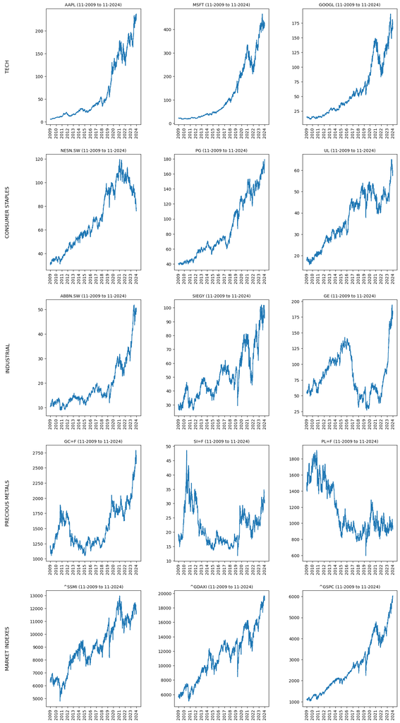

```python
# prepare plot
num_rows = len(assets)
figures, axs = plt.subplots(num_rows, 3 + 1, figsize=(15, num_rows * 5), gridspec_kw={'width_ratios': [0.1] + [1] * 3}, squeeze=False)
figures.tight_layout(pad=5)

for i, (assetType, group) in enumerate(assets.items()): # for each group of assets
    # add group name on the left of the asset plots
    axs[i, 0].text(0.5, 0.5, assetType.upper().replace('_',' '), va='center', ha='center', fontsize=12, rotation=90)
    axs[i, 0].axis('off') # disable axis for group name

    for j, (ticker, prices) in enumerate(group.items()): # for each asset in the group
        if j + 1 >= axs.shape[1]: # if there are more than 3 tickers in the group, skip the rest to keep visualization clean
            print(f"Warnung: Mehr als 3 Ticker in Gruppe '{assetType}', zusätzliche werden nicht angezeigt.")
            continue

        ax = axs[i, j + 1]

        # plot asset prices
        ax.plot(prices)

        # add x-axis labels for each year
        date_range = pd.date_range(start=START_DATE, periods=len(prices))
        ticks = np.linspace(0, len(prices) - 1, 16, dtype=int)
        ax.set_xticks(ticks)
        ax.set_xticklabels(date_range[ticks].strftime('%Y'), rotation=90)

        # set title for the asset plot
        ax.set_title(f"{ticker} (11-2009 to 11-2024)", fontsize=10)

plt.show()
```

## 6. Daten aufbereiten

Die vorgegebene Literatur (*'Technical Analysis for Algorithmic Pattern Recognition'* von Tsinaslanidis & Zapranis (2016)) beschreibt mehrere Schritte zur Datenaufbereitung, die für eine effektive Mustererkennung mittels DTW, konkret mittels subsequence DDTW, erforderlich sind. Diese Schritte müssen spezifisch auf die Referenz- und Vergleichssequenzen angewendet werden. Daher erfolgt in diesem Schritt keine vollständige Datenaufbereitung. Stattdessen werden Funktionen bereitgestellt, die eine gezielte und flexible Anwendung der Aufbereitung ermöglichen. (Eine globale Bearbeitung der gesamten Zeitreihe anstelle der individuellen Teilsequenzen könnte insbesondere bei Prozessen wie Glättung oder Skalierung zu unerwünschten Verzerrungen führen.)

Um die Funktionalität der einzelnen Aufbereitungsschritte zu prüfen und ihre Auswirkungen aufzuzeigen, werden diese exemplarisch anhand einer vollständigen Zeitreihe eines Assets demonstriert. Dies ermöglicht eine Visualisierung und eine gezielte Analyse der Effekte, die jeder Aufbereitungsschritt auf die Zeitreihe hat.

### 6.1. Daten glätten

Angelehnt an das Beispiel in der Literatur wird die Zeitreihe mit dem Savitzky-Golay-Algorithmus geglättet, um das Rauschen der Daten zu reduzieren, ohne dabei wesentliche Muster zu verfälschen. Für die Glättung werden, wie im Beispiel der Literatur, in einer ersten Phase ein kubischer Polynomgrad (3) und eine Fenstergrösse von 21 verwendet. Diese Parameter sollen eine Balance zwischen Rauschunterdrückung und dem Erhalt lokaler Muster bilden. Durch die Glättung werden die im nächsten Schritt berechneten Ableitungen stabiler und weniger anfällig für Ausreisser. Dabei ist darauf zu achten, dass die Glättung nicht zu stark gewählt wird, um relevante Details der Zeitreihe zu erhalten.

Dieser Algorithmus ist unter dem Namen *savgol_filter* in der *SciPy*-Library verfügbar und ermöglicht eine effiziente und einfache Implementierung der Savitzky-Golay-Glättung. Der nachfolgende, einfache Wrapper basiert auf dieser etablierten Implementierung und nutzt ihre Flexibilität zur Anpassung von Parametern wie Fenstergrösse und Polynomgrad.

```python
def smoothTimeSeries(timeSeries, polyOrder=3, windowSize=21):
    """
    Function to smooth a time series using Savitzky-Golay filter.

    Args:
        timeSeries: time series data
        polyOrder: polynomial order (default is 3)
        windowSize: window size (default is 21)

    Returns:
        smoothedTimeSeries: smoothed time series data
    """
    return scipy.signal.savgol_filter(timeSeries, windowSize, polyOrder)
```

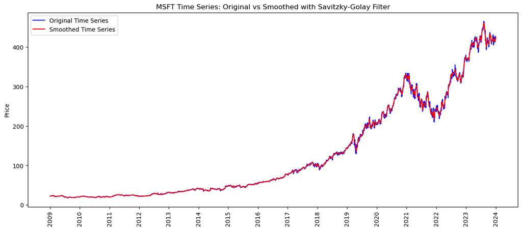

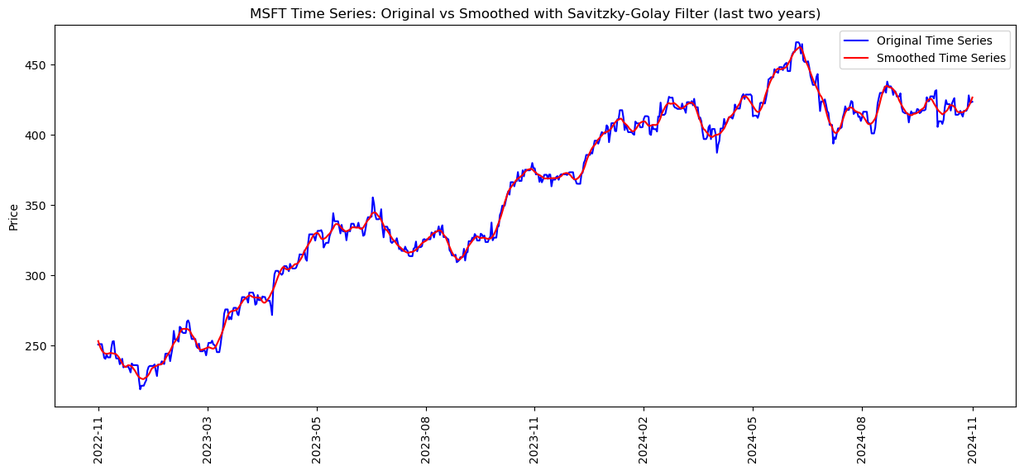

```python
ASSET_TYPE = 'tech' # type of asset to analyze
ASSET_TICKER = 'MSFT' # ticker of asset to analyze

# Original time series
original_series = assets[ASSET_TYPE][ASSET_TICKER]

# Smoothed time series
smoothed_series = smoothTimeSeries(original_series)

# Plotting
plt.figure(figsize=(15, 6))
plt.plot(original_series, label='Original Time Series', color='blue')
plt.plot(smoothed_series, label='Smoothed Time Series', color='red')
plt.title(f'{ASSET_TICKER} Time Series: Original vs Smoothed with Savitzky-Golay Filter')
date_range = pd.date_range(start=START_DATE, periods=len(original_series))
ticks = np.linspace(0, len(original_series) - 1, 16, dtype=int)
plt.xticks(ticks, date_range[ticks].strftime('%Y'), rotation=90)
plt.ylabel('Price')
plt.legend()
plt.show()

# Plotting the last two years of data to show the smoothing effect "zoomed in"
num_days_shown = 2 * 365
original_series_shortened = original_series[-num_days_shown:]
smoothed_series_shortened = smoothTimeSeries(original_series_shortened)

# Plotting
plt.figure(figsize=(15, 6))
plt.plot(original_series_shortened, label='Original Time Series', color='blue')
plt.plot(smoothed_series_shortened, label='Smoothed Time Series', color='red')
plt.title(f'{ASSET_TICKER} Time Series: Original vs Smoothed with Savitzky-Golay Filter (last two years)')
date_range_shortened = pd.date_range(start=pd.Timestamp(END_DATE) - pd.DateOffset(years=2), periods=num_days_shown)
ticks_shortened = np.linspace(0, num_days_shown - 1, 9, dtype=int)
plt.xticks(ticks_shortened, date_range_shortened[ticks_shortened].strftime('%Y-%m'), rotation=90)
plt.ylabel('Price')
plt.legend()
plt.show()
```

### 6.2. Erste Ableitung berechnen

```python
def calculateDerivatives(timeSeries):
    """
    Function to calculate the first derivatives of a time series.

    Args:
        timeSeries: time series data

    returns:
        derivatives: series of first derivatives of the time series
    """

    derivatives = np.zeros_like(timeSeries) # initialize the derivatives array
    for i in range(1, len(timeSeries) - 1):
        derivatives[i] = ((timeSeries[i]-timeSeries[i-1]) + 0.5*(timeSeries[i+1]-timeSeries[i-1])) / 2 # according to formula (9.11) in the book

    return derivatives
```

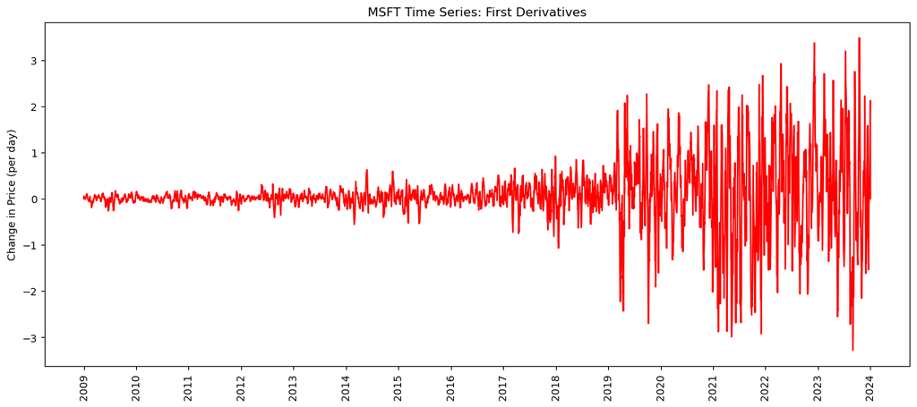

```python
# First derivatives of the smoothed time series
first_derivatives = calculateDerivatives(smoothed_series)

# Plotting
plt.figure(figsize=(15, 6))
plt.plot(first_derivatives, color='red')
plt.title(f'{ASSET_TICKER} Time Series: First Derivatives')
date_range = pd.date_range(start=START_DATE, periods=len(original_series))
ticks = np.linspace(0, len(original_series) - 1, 16, dtype=int)
plt.xticks(ticks, date_range[ticks].strftime('%Y'), rotation=90)
plt.ylabel('Change in Price (per day)')
plt.show()
```

### 6.3. Daten standardisieren

Der letzte Schritt zur Aufbereitung der Daten besteht darin, diese zu standardisieren. Ziel der Standardisierung ist es, die Werte der Zeitreihe auf einen einheitlichen Massstab zu transformieren, um Verzerrungen durch unterschiedliche Grössenordnungen oder Einheiten zu vermeiden. Dadurch wird die Vergleichbarkeit zwischen der Referenz- und der Vergleichssequenz erheblich verbessert.

In der vorgegebenen Literatur wird hierfür die weitverbreitete Z-Transformation angewendet (auch wenn sie nicht explizit erwähnt wird). Diese Transformation passt die Werte so an, dass die Zeitreihe einen Mittelwert von 0 und eine Standardabweichung von 1 aufweist. Eine Funktion zur Durchführung der Z-Transformation wird im Folgenden implementiert und demonstriert.

```python
def standardizeData(timeSeries):
    """
    Function to standardize a time series.

    Args:
        timeSeries: time series data

    returns:
        standardizedTimeSeries: standardized time series data
    """
    timeSeries = np.array(timeSeries) # convert to numpy array if not already
    return (timeSeries - np.mean(timeSeries)) / np.std(timeSeries)
```

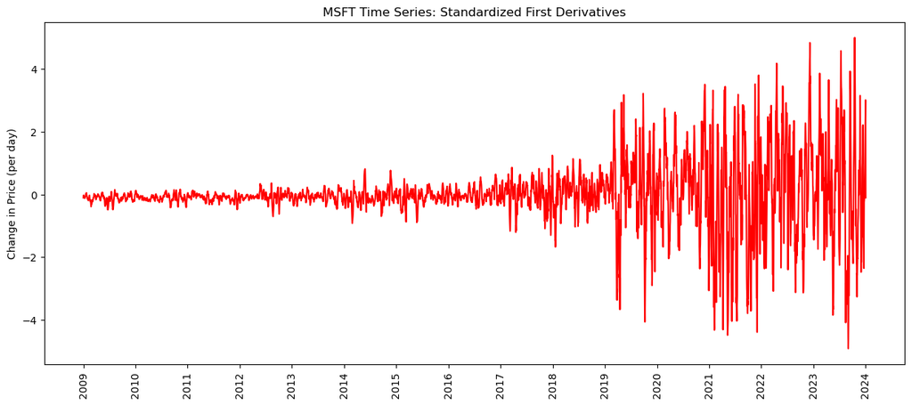

```
Mean of first derivatives: 0.07343591169982781
Standard deviation of first derivatives: 0.6822785137758796
Mean of standardized first derivatives: -0.0
Standard deviation of standardized first derivatives: 1.0
```

```python
# Standardized first derivatives
standardized_first_derivatives = standardizeData(first_derivatives)

# Plotting
plt.figure(figsize=(15, 6))
plt.plot(standardized_first_derivatives, color='red')
plt.title(f'{ASSET_TICKER} Time Series: Standardized First Derivatives')
date_range = pd.date_range(start=START_DATE, periods=len(original_series))
ticks = np.linspace(0, len(original_series) - 1, 16, dtype=int)
plt.xticks(ticks, date_range[ticks].strftime('%Y'), rotation=90)
plt.ylabel('Change in Price (per day)')
plt.show()


# Calculate the mean and standard deviation of the first derivatives and standardized first derivatives
print(f'Mean of first derivatives: {np.mean(first_derivatives)}')
print(f'Standard deviation of first derivatives: {np.std(first_derivatives)}')

print(f'Mean of standardized first derivatives: {round(np.mean(standardized_first_derivatives),15)}') # round to avoid scientific notation in case of floating point error
print(f'Standard deviation of standardized first derivatives: {np.std(standardized_first_derivatives)}')
```

## 7. Distanzfunktion mit Dynamic Time Warping

Zentral für die Mustererkennung im vorliegenden Anwendungsfall ist das Dynamic Time Warping (DTW). Es handelt sich dabei um ein Distanzmass, das die Ähnlichkeit zwischen zwei Zeitreihen berechnet, selbst wenn diese in Länge oder Timing variieren. Die DTW-Distanz basiert auf der Minimierung der kumulierten Abweichungen entlang eines sogenannten Warping-Pfades. Dieser Pfad definiert, wie die Zeitpunkte der beiden Zeitreihen aufeinander abgebildet werden können, um eine optimale Übereinstimmung zu erzielen. Eine niedrige DTW-Distanz geht dementsprechend mit einer hohen Ähnlichkeit der zwei verglichenen Zeitreihen einher.

### 7.1. DTW Grundfunktionalität

Für die Implementation wird die dtw-Funktionalität von tslearn eingesetzt und nachfolgend exemplarisch eingesetzt. Dabei werden in diesem ersten Beispiel die Distanz der geglätteten Werte (nicht Ableitungen) der Aktion von Apple und Google berechnet und das Alignment dieser zwei Zeitserien visualisiert.

```
Berechnete DTW Distance zwischen AAPL und GOOGL: 758.41
```

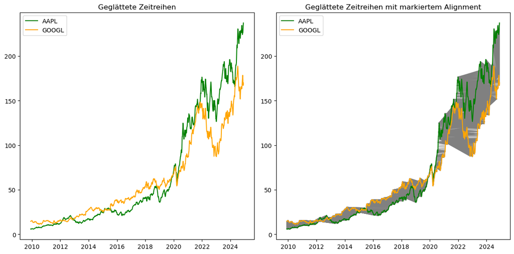

```python
cmpData = [
    { 'type': 'tech', 'ticker': 'AAPL' },
    { 'type': 'tech', 'ticker': 'GOOGL' },
]

# check if exactly two assets are provided for comparison
if len(cmpData) != 2:
    raise ValueError('Exactly two assets must be provided for comparison.')

# add smoothed prices to comparisionData
for assetIndex, asset in enumerate(cmpData):
    cmpData[assetIndex]['rawPrices'] = assets[asset['type']][asset['ticker']]
    cmpData[assetIndex]['smoothedPrices'] = smoothTimeSeries(cmpData[assetIndex]['rawPrices']) # smooth the prices

# calculate the DTW distance and path for the two assets
dtw_distance = tslearn.metrics.dtw(cmpData[0]['smoothedPrices'], cmpData[1]['smoothedPrices'])
path, cost = tslearn.metrics.dtw_path(cmpData[0]['smoothedPrices'], cmpData[1]['smoothedPrices'])
print(f'Berechnete DTW Distance zwischen {cmpData[0]["ticker"]} und {cmpData[1]["ticker"]}: {dtw_distance:.2f}')

# plot the smoothed time series to allow visual inspection of the alignment between the two assets (left plot)
plt.figure(figsize=(12, 6))
plt.subplot(1, 2, 1)
plt.plot(dates,cmpData[0]['smoothedPrices'], label=cmpData[0]['ticker'], color='green')
plt.plot(dates,cmpData[1]['smoothedPrices'], label=cmpData[1]['ticker'], color='orange')
plt.title('Geglättete Zeitreihen')
plt.legend()

# plot the DTW warping path providing a visual representation of the alignment of the two time series (right plot)
plt.subplot(1, 2, 2)
for (i, j) in path:
    plt.plot([dates[i], dates[j]], [cmpData[0]['smoothedPrices'][i], cmpData[1]['smoothedPrices'][j]], color='gray', alpha=0.5)
plt.plot(dates,cmpData[0]['smoothedPrices'], label=cmpData[0]['ticker'], color='green')
plt.plot(dates,cmpData[1]['smoothedPrices'], label=cmpData[1]['ticker'], color='orange')
plt.title('Geglättete Zeitreihen mit markiertem Alignment')
plt.legend()

plt.tight_layout()
plt.show()
```

Da die beiden Zeitreihen über einen Zeitraum von 15 Jahren verglichen wurden und neben der Glättung keine weiteren Vorverarbeitungsschritte, wie die Berechnung der ersten Ableitung oder eine Standardisierung mittels Z-Skalierung, durchgeführt wurden, fällt die berechnete DTW-Distanz relativ hoch aus. Zudem ist der DTW-Alignment-Pfad aufgrund der langen Zeitspanne und fehlenden Normalisierung relativ unübersichtlich.

### 7.2. Derivative DTW

Im nächsten Schritt sollen die beiden Zeitreihen daher auf das letzte Jahr der bezogenen Daten eingegrenzt werden. Zusätzlich wird die Analyse auf Basis der ersten Ableitung (also mit Derivative DTW bzw. DDTW) und unter Anwendung einer Standardisierung erfolgen.

```
Berechnete DTW Distance zwischen AAPL und GOOGL: 8.39
```

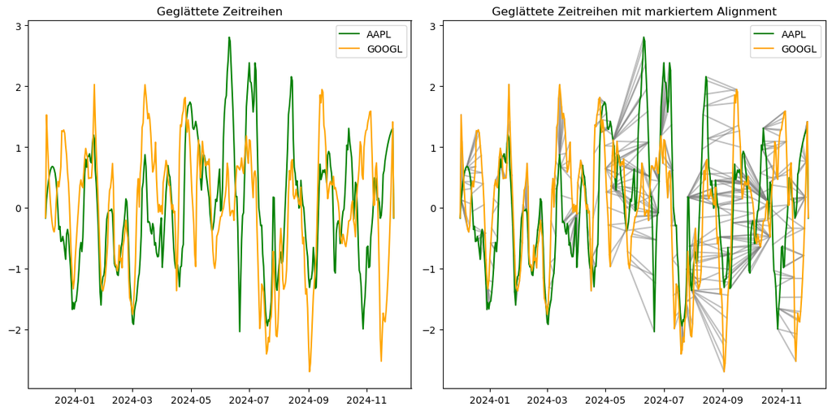

```python
daysToCompare = 365 # number of days to use for comparison (beginning from the end of the time series)

for assetIndex, asset in enumerate(cmpData):
    cmpData[assetIndex]['rawPrices'] = assets[asset['type']][asset['ticker']][-daysToCompare:]          # get the last daysToCompare days of raw prices
    cmpData[assetIndex]['smoothedPrices'] = smoothTimeSeries(cmpData[assetIndex]['rawPrices'])          # smooth the prices
    cmpData[assetIndex]['derivatives'] = calculateDerivatives(cmpData[assetIndex]['smoothedPrices'])    # calculate the derivatives
    cmpData[assetIndex]['stdDerivatives'] = standardizeData(cmpData[assetIndex]['derivatives'])         # standardize the derivatives

# calculate the DTW distance and path for the two assets
dtw_distance = tslearn.metrics.dtw(cmpData[0]['stdDerivatives'], cmpData[1]['stdDerivatives'])
path, cost = tslearn.metrics.dtw_path(cmpData[0]['stdDerivatives'], cmpData[1]['stdDerivatives'])
print(f'Berechnete DTW Distance zwischen {cmpData[0]["ticker"]} und {cmpData[1]["ticker"]}: {dtw_distance:.2f}')

# plot the smoothed time series to allow visual inspection of the alignment between the two assets (left plot)
plt.figure(figsize=(12, 6))
plt.subplot(1, 2, 1)
plt.plot(dates[-daysToCompare:],cmpData[0]['stdDerivatives'], label=cmpData[0]['ticker'], color='green')
plt.plot(dates[-daysToCompare:],cmpData[1]['stdDerivatives'], label=cmpData[1]['ticker'], color='orange')
plt.title('Geglättete Zeitreihen')
plt.legend()

# plot the DTW warping path providing a visual representation of the alignment of the two time series (right plot)
plt.subplot(1, 2, 2)
for (i, j) in path:
    plt.plot([dates[-daysToCompare:][i], dates[-daysToCompare:][j]], [cmpData[0]['stdDerivatives'][i], cmpData[1]['stdDerivatives'][j]], color='gray', alpha=0.5)
plt.plot(dates[-daysToCompare:],cmpData[0]['stdDerivatives'], label=cmpData[0]['ticker'], color='green')
plt.plot(dates[-daysToCompare:],cmpData[1]['stdDerivatives'], label=cmpData[1]['ticker'], color='orange')
plt.title('Geglättete Zeitreihen mit markiertem Alignment')
plt.legend()

plt.tight_layout()
plt.show()
```

Durch die vorgenommenen Änderungen ist die DTW-Distanz zwischen den zwei Zeitreihen deutlich gesunken, da systematische Unterschiede reduziert wurden. Die Grafiken bestätigen dies, indem sie zeigen, dass die Zeitreihen durch Normalisierungsschritte wie Glätten, Ableitung und Standardisierung nun besser vergleichbar sind. Die reduzierte DTW-Distanz und der weniger verzerrte Warping-Pfad verdeutlichen diese Verbesserung. Das Alignment in der rechten Grafik zeigt zudem, dass die Zeitreihen in einigen Phasen, etwa von Mitte Januar bis Mitte März sowie Mitte Juli, zeitlich hohe Übereinstimmungen aufweisen und praktisch nicht verzerrt werden mussten. In anderen Phasen waren jedoch wesentliche Verzerrungen notwendig, um die Zeitreihen anzugleichen.

### 7.3. DTW-Kostenmatrix und Warping-Pfad

Neben dem zuvor dargestellten Alignment existieren weitere zweckmässige Möglichkeiten, den Warping-Pfad zu visualisieren. Besonders hilfreich ist dabei die Kostenmatrix, welche die paarweisen Kosten zwischen allen Werten der beiden Zeitreihen darstellt. Helle Bereiche symbolisieren hohe Kosten, dunkle Bereiche niedrige Kosten (vgl. Grafiken in der oberen Zeile). Das Ziel von DTW ist es, einen Pfad von oben links (Startdatum beider Zeitreihen) nach unten rechts (Enddatum beider Zeitreihen) zu finden, der die Gesamtkosten minimiert. Dieser optimale Pfad ist im rechten oberen Bild hervorgehoben.

Das linke untere Bild konzentriert sich ausschliesslich auf den optimalen Warping-Pfad und zeigt die Kosten der einzelnen Zuordnungen entlang des Pfads. Diese Kosten werden wiederum durch die Farbintensität visualisiert, während die Abweichung vom diagonalen Verlauf verdeutlicht, wie stark die Zeitreihen zeitlich verzerrt oder verschoben werden mussten.

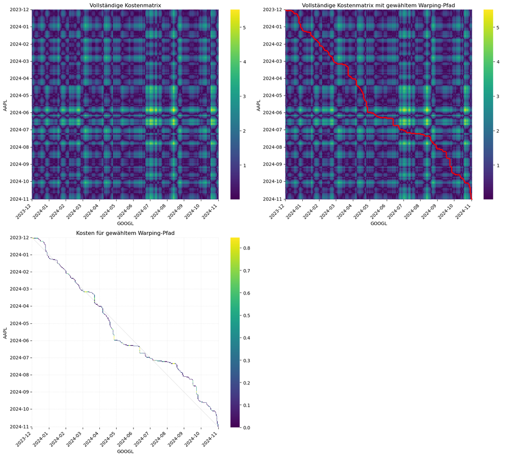

```python
# calculate full and sparse cost matrices for the two assets
full_cost_matrix = np.abs(np.array(cmpData[0]['stdDerivatives'])[:, None] - np.array(cmpData[1]['stdDerivatives'])[None, :])
sparse_cost_matrix = np.full_like(full_cost_matrix, np.inf)
for i, j in path:
    sparse_cost_matrix[i, j] = full_cost_matrix[i, j] # fill the sparse cost matrix with the values from the full cost matrix along the alignment path

# define the ticks and labels for the heatmaps
ticks = np.linspace(0, daysToCompare - 1, 12, dtype=int) # one tick per month
labels = [str(dates[-daysToCompare:][j])[:7] for j in ticks] # get the first 7 characters of the date strings for each tick ('YYYY-MM')

# helper function to set the ticks and labels for the heatmaps to reduce redundancy
def setTicksAndLabels(ax):
    ax.set_xticks(ticks)
    ax.set_yticks(ticks)
    ax.set_xticklabels(labels, rotation=45, ha='right')
    ax.set_yticklabels(labels, rotation=0)
    return ax

# create plot grid for cost matrices
figures, axs = plt.subplots(2, 2, figsize=(16, 14))

# full cost matrix (upper left plot)
sns.heatmap(full_cost_matrix, cmap='viridis', cbar=True, ax=axs[0, 0])
setTicksAndLabels(axs[0, 0])
axs[0, 0].set_title('Vollständige Kostenmatrix')
axs[0, 0].set_ylabel(cmpData[0]['ticker'])
axs[0, 0].set_xlabel(cmpData[1]['ticker'])

# full cost matrix with marked warping path (upper right plot)
sns.heatmap(full_cost_matrix, cmap='viridis', cbar=True, ax=axs[0, 1])
setTicksAndLabels(axs[0, 1])
for (i, j) in path:
    axs[0, 1].plot(j + 0.5, i + 0.5, 'r.', markersize=3)
axs[0, 1].set_title('Vollständige Kostenmatrix mit gewähltem Warping-Pfad')
axs[0, 1].set_ylabel(cmpData[0]['ticker'])
axs[0, 1].set_xlabel(cmpData[1]['ticker'])

# plot the sparse cost matrix for warping path (lower left plot)
sns.heatmap(sparse_cost_matrix, cmap='viridis', cbar=True, ax=axs[1, 0],
            vmin=0, vmax=np.nanmax(np.where(sparse_cost_matrix != np.inf, sparse_cost_matrix, np.nan)) * 0.5)
setTicksAndLabels(axs[1, 0])
diagonal = range(min(daysToCompare, daysToCompare))
axs[1, 0].plot(diagonal, diagonal, color='grey', linestyle='--', linewidth=0.5, alpha=0.5)
axs[1, 0].grid(color='gray', linestyle='--', linewidth=0.5, alpha=0.2)
axs[1, 0].set_title('Kosten für gewähltem Warping-Pfad')
axs[1, 0].set_ylabel(cmpData[0]['ticker'])
axs[1, 0].set_xlabel(cmpData[1]['ticker'])

# leave the lower right plot empty
axs[1, 1].axis('off')

plt.tight_layout()
plt.show()
```

### 7.4. Vergleich der verzerrten Zeitreihen und abgeleitete Kosten

Nachfolgend werden zwei ergänzende Visualisierungen dargestellt, welche die Ergebnisse der DTW-Analyse verdeutlichen. Im ersten Diagramm werden die Zeitreihen nach der Anpassung durch DTW gezeigt. Dabei wird die Differenz zwischen den beiden verzerrten Zeitreihen durch grau hinterlegte Flächen visualisiert, welche die paarweisen Distanzen darstellen. Da die ursprünglichen Zeitreihen nicht perfekt aligned sind (erkennbar daran, dass z.B. der Warping-Pfad in der vorherigen Grafik nicht der idealen Diagonalen entspricht), enthält die X-Achse mehr Einträge. Diese zusätzlichen Einträge entstehen durch die Wiederholung einzelner Werte entlang des Warping-Pfads, was in der Grafik als Plateaus sichtbar wird. Im zweiten Diagramm werden die Kosten entlang des Warping-Pfads explizit dargestellt. Die Werte entsprechen den paarweisen Distanzen aus dem ersten Diagramm (grau markiert). Sie korrelieren dabei direkt mit der Farbcodierung der Kostenmatrix und verdeutlichen, in welchen Bereichen die Anpassungen hohe oder niedrige Kosten verursacht haben.

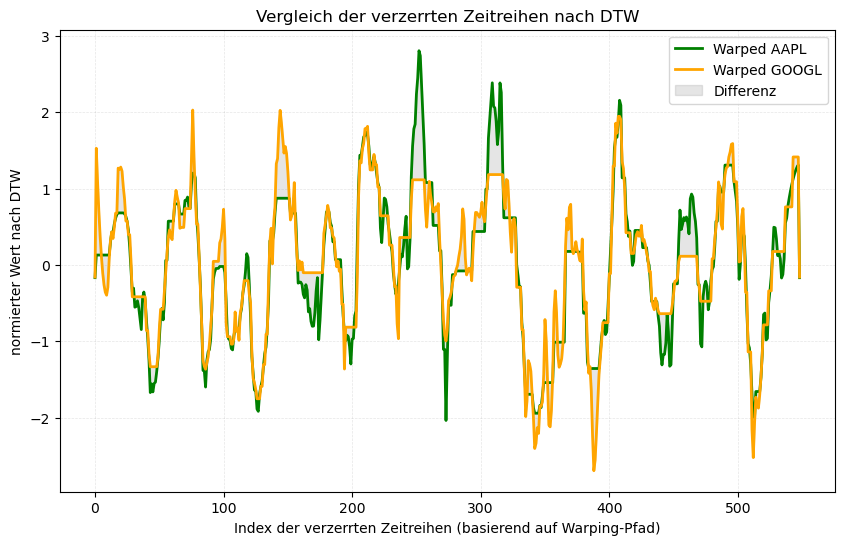

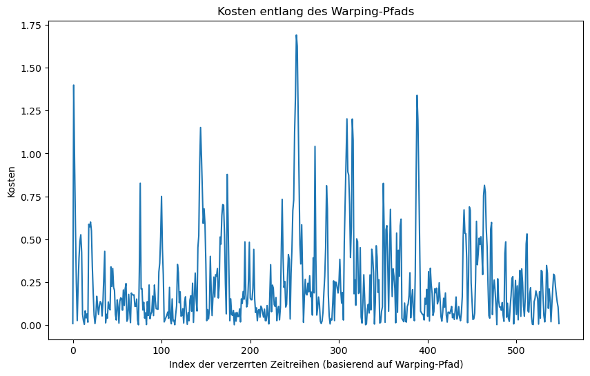

```python
# calculate the warped time series for the two assets
cmpData[0]['warped'] = [cmpData[0]['stdDerivatives'][i] for i, j in path]
cmpData[1]['warped'] = [cmpData[1]['stdDerivatives'][j] for i, j in path]

# plot the warped time series
plt.figure(figsize=(10, 6))
plt.plot(cmpData[0]['warped'], label=f"Warped {cmpData[0]['ticker']}", color="green", linewidth=2)
plt.plot(cmpData[1]['warped'], label=f"Warped {cmpData[1]['ticker']}", color="orange", linewidth=2)
plt.fill_between(range(len(cmpData[0]['warped'])),cmpData[0]['warped'], cmpData[1]['warped'], color='grey', alpha=0.2, label="Differenz") # show the difference between the two time series as a shaded area
plt.grid(color='gray', linestyle='--', linewidth=0.5, alpha=0.2) # add grid
plt.legend() # show the legend
plt.title('Vergleich der verzerrten Zeitreihen nach DTW')
plt.ylabel('normierter Wert nach DTW')
plt.xlabel('Index der verzerrten Zeitreihen (basierend auf Warping-Pfad)')
plt.show()

# plot the costs along the warping path
plt.figure(figsize=(10, 6))
plt.plot([full_cost_matrix[i, j] for i, j in path])
plt.title('Kosten entlang des Warping-Pfads')
plt.ylabel('Kosten')
plt.xlabel('Index der verzerrten Zeitreihen (basierend auf Warping-Pfad)')
plt.show()
```

## 8. Subsequence DTW

Gemäss vorgegebener Literatur (*'Technical Analysis for Algorithmic Pattern Recognition'* von Tsinaslanidis & Zapranis (2016)) soll die Analyse für die Mustererkennung auf Subsequence DTW basieren. Dabei wird DTW, anders als im vorherigen Kapitel, nicht für den Vergleich zwischen Zeitreihen unterschiedlicher Assets verwendet, sondern für die Analyse von Teilsequenzen innerhalb einer Zeitreihe eines Assets.

Für diese Methode ist es erforderlich, ein Zeitfenster festzulegen, das die Länge der betrachteten Sequenz definiert. Auf Basis dieses Zeitfensters wird die sogenannte Query-Sequenz ermittelt, die typischerweise aus dem Ende der Zeitreihe stammt. Dies ist besonders relevant, da die Methode zur Prognose von Kursentwicklungen getestet wird und davon ausgegangen wird, dass kürzlich stattgefundene Kursentwicklungen tendenziell einen grösseren Einfluss auf zukünftige Bewegungen haben als weiter zurückliegende Ereignisse.

### 8.1. Distanzermittlung von Subsequenzen zu Referenzsequenz

Im ersten Schritt werden die (D)DTW-Distanzen zwischen allen verfügbaren Subsequenzen, die innerhalb des festgelegten Zeitfensters liegen, und der Referenzsequenz berechnet. Eine wichtige Voraussetzung hierfür ist die separate Normalisierung der Daten für jede Subsequenz, um Verzerrungen durch globale Eigenschaften der gesamten Zeitreihe zu vermeiden. Das Ziel dieses Schritts ist es, eine Reihe von Distanzen zu erhalten, die es ermöglichen, die Subsequenzen zu identifizieren, die der Referenzsequenz am ähnlichsten sind. Diese Ähnlichkeit wird anhand der minimalen (D)DTW-Distanz bewertet, wobei kleinere Werte auf eine engere Übereinstimmung hinweisen.

```python
def calculateSubsequenceDistances(timeSeries, referenceSequence=None, windowSize=30):
    """
    Function to calculate the distances between subsequences of a time series and a reference series.

    Args:
        timeSeries: time series data
        referenceSequence: referenceSequence (use latest subsequence if None, default is None)
        windowSize: window size for subsequence extraction (default is SUBSEQUECE_WINDOW)

    Returns:
        distances: distances between subsequences of the time series and the reference series
    """

    if referenceSequence is None: # if no reference series is provided, use the latest subsequence as reference
        referenceSequence = timeSeries[-windowSize:]

    # normalize the reference series (only once as it is constant)
    referenceSequence = standardizeData(calculateDerivatives(smoothTimeSeries(referenceSequence)))

    distances = np.zeros(len(timeSeries) - windowSize + 1) # contains the distances for each subsequence to the reference sequence
    for i in range(len(timeSeries) - windowSize + 1): # calculate the distances for each subsequence
        # normalize the subsequence
        subsequence = standardizeData(calculateDerivatives(smoothTimeSeries(timeSeries[i:i + windowSize])))
        distances[i] = tslearn.metrics.dtw(subsequence, referenceSequence) # calculate the DTW distance between the subsequence and the reference series

    return distances
```

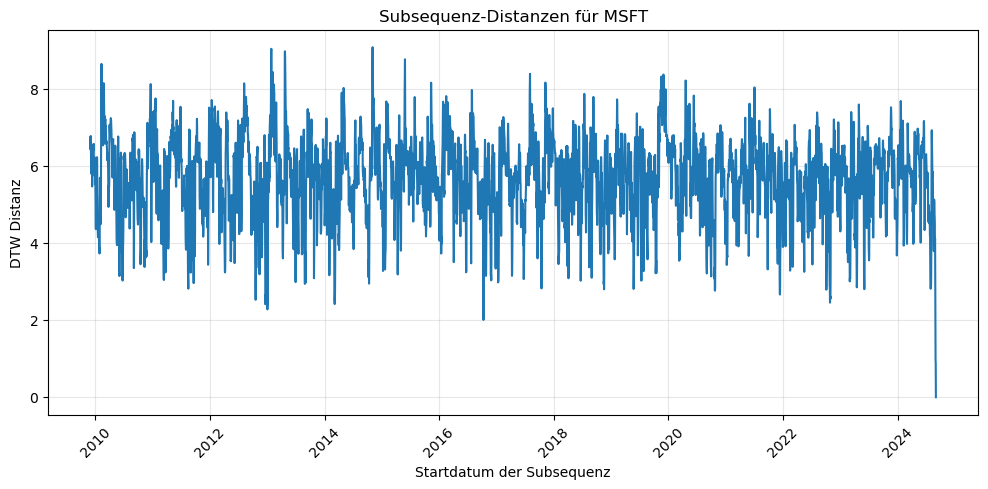

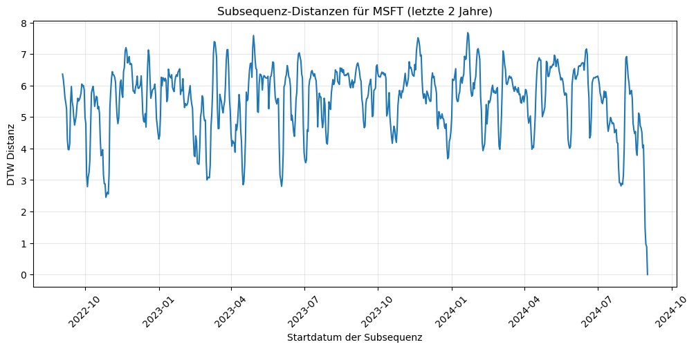

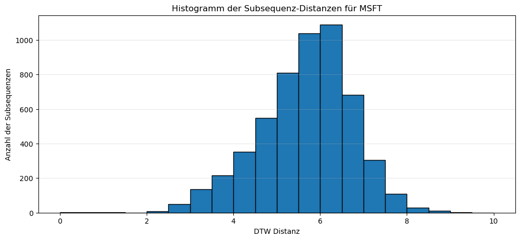

```python
SUBSEQUECE_WINDOW = 90      # window size for subsequence extraction
ASSET_TYPE = 'tech'         # asset type
ASSET_TICKER = 'MSFT'       # asset ticker

# calculate the subsequence distance for the Apple stock data
distances = calculateSubsequenceDistances(assets[ASSET_TYPE][ASSET_TICKER], windowSize=SUBSEQUECE_WINDOW)

# plot the subsequence distances for full time series
plt.figure(figsize=(12, 5))
plt.plot(dates[:len(dates)-SUBSEQUECE_WINDOW+1], distances)
plt.title(f'Subsequenz-Distanzen für {ASSET_TICKER}')
plt.ylabel('DTW Distanz')
plt.xlabel('Startdatum der Subsequenz')
plt.xticks(rotation=45)
plt.grid(alpha=0.3)
plt.show()

# plot the subsequence distances for the last 2 years of data for better visibility
plt.figure(figsize=(12, 5))
recent_start_index = max(0, len(dates) - 2 * 365 - SUBSEQUECE_WINDOW + 1)  # use only the last 2 years of data
plt.plot(dates[recent_start_index:len(dates) - SUBSEQUECE_WINDOW + 1], distances[recent_start_index:])
plt.title(f'Subsequenz-Distanzen für {ASSET_TICKER} (letzte 2 Jahre)')
plt.ylabel('DTW Distanz')
plt.xlabel('Startdatum der Subsequenz')
plt.xticks(rotation=45)
plt.grid(alpha=0.3)
plt.show()

# histogram of the subsequences distances
plt.figure(figsize=(12, 5))
bin_width = 0.5
plt.hist(distances, bins=np.arange(np.floor(min(distances)), np.ceil(max(distances)) + bin_width, bin_width), edgecolor='black')
plt.title(f'Histogramm der Subsequenz-Distanzen für {ASSET_TICKER}')
plt.xlabel('DTW Distanz')
plt.ylabel('Anzahl der Subsequenzen')
plt.grid(axis='y', alpha=0.3)
plt.show()
```

In diesen Grafiken lassen sich Bereiche erkennen, in denen die DTW-Distanz deutlich abfällt. Dies deutet darauf hin, dass die geprüfte Subsequenz der Referenzsequenz ähnelt. Am Ende der Zeitreihe fällt die Distanz sogar auf 0, da an dieser Stelle die Subsequenz mit der Referenzsequenz übereinstimmt. Da es sich dabei um dieselbe Sequenz handelt, ist es folgerichtig, dass die Distanz dementsprechend 0 beträgt, entsprechend der Definition der DTW-Distanz.

Die dritte Grafik zeigt ein Histogramm der berechneten Distanzen. Dieses veranschaulicht die Verteilung der Distanzen und hilft dabei, die Häufigkeit unterschiedlicher Ähnlichkeitsstufen zwischen den Subsequenzen und der Referenzsequenz zu analysieren.

### 8.2. Ermitteln von ähnlichen Sequenzen

Die vorgegebene Literatur (*'Technical Analysis for Algorithmic Pattern Recognition'* von Tsinaslanidis & Zapranis (2016)) schlägt vor, anschliessend in der Serie der DTW-Distanzen lokale Minima mithilfe der rw-Funktion zu ermitteln. Diese Methode verhindert, dass nahe beieinander liegende Subsequenzen mit ähnlichen, niedrigen Distanzen zur Referenzsequenz fälschlicherweise als separate Treffer betrachtet werden. Stattdessen wählt die Funktion das beste Minimum innerhalb eines festgelegten Fensters, um Redundanzen zu vermeiden und die Ergebnisse zu konsolidieren.

Zusätzlich wird ein Schwellenwert (Threshold) definiert, unterhalb dessen die gefundenen Minima liegen müssen, um weiter berücksichtigt zu werden. Dieser Threshold stellt sicher, dass nur Minima in relevanten, niedrigen Distanzbereichen beachtet werden, während irrelevante Minima in hohen Distanzbereichen ausgeschlossen bleiben.

```python
def getRelevantBottoms(distances, subsequenceWindow, rollingWindowFactor=3, thresholdFactor=1/30, showPlot=False): # note: default factors where chosen based on empirical observations and might need to be adjusted when calling the function
    """
    Function to detect relevant bottoms in the subsequence distances.

    Args:
        distances: distances between subsequences of the time series and the reference series
        subsequenceWindow: window size for subsequence extraction
        rollingWindowFactor: factor for rolling window size calculation based on subsequence window (default is 3)
        thresholdFactor: factor for threshold calculation based on subsequence window (default is 1/30)
        showPlot: plot flag (default is False)

    Returns:
        relevantBottoms: relevant bottoms coordinates
        irrelevantBottoms: irrelevant bottoms coordinates
        threshold: threshold value
    """
    rollingWindow = subsequenceWindow * rollingWindowFactor
    minimaThreshold = subsequenceWindow * thresholdFactor

    # get the peaks and bottoms of the subsequences
    _,bottoms = rw(distances, rollingWindow, showPlot)


    # filter the bottoms based on the threshold
    relevantBottoms = bottoms[bottoms[:, 0] < minimaThreshold] if len(bottoms) > 0 else []
    irrelevantBottoms = bottoms[bottoms[:, 0] >= minimaThreshold] if len(bottoms) > 0 else []

    return relevantBottoms, irrelevantBottoms, minimaThreshold
```

```
Gefundene 'Bottoms' unter dem Grenzwert (3.00):
  Startdatum der Subsequenz  DTW Distanz
0                2011-08-16     2.814770
1                2013-01-01     2.278225
2                2014-03-06     2.415438
3                2016-10-09     2.003998
4                2017-10-14     2.820505
5                2018-11-17     2.798501
6                2020-10-24     2.762669
7                2021-12-12     2.662674
8                2022-10-27     2.452218
```

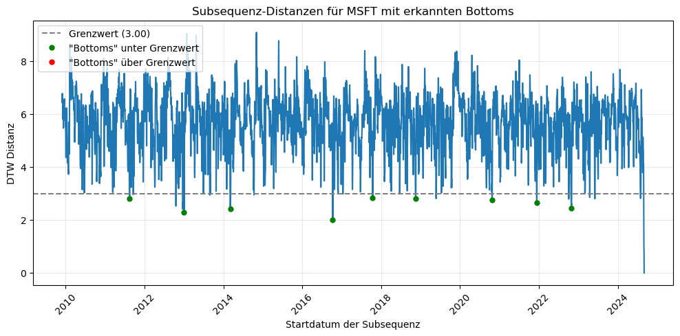

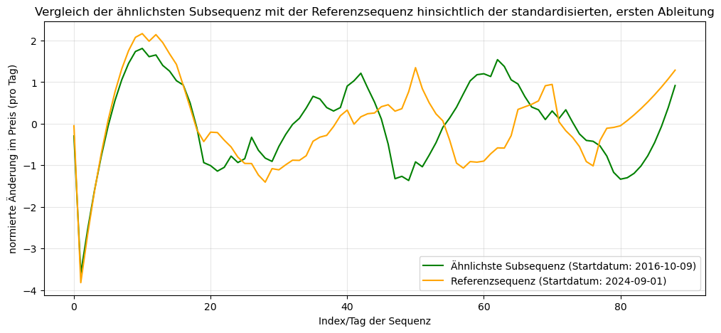

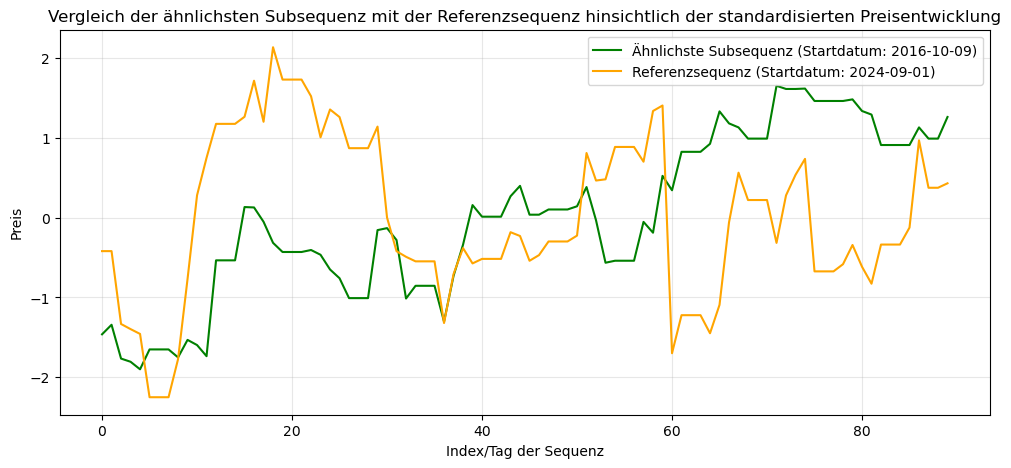

```python
# detect relevant and irrelevant bottoms of the subsequence distances
relevantBottoms, irrelevantBottoms, minimaThreshold = getRelevantBottoms(distances, SUBSEQUECE_WINDOW)

# table of relevant bottoms
bottomsTable = pd.DataFrame(relevantBottoms, columns=['DTW Distanz', 'Index'])
bottomsTable['Startdatum der Subsequenz'] = pd.to_datetime(dates)[bottomsTable['Index'].astype(int)].strftime('%Y-%m-%d')
bottomsTable = bottomsTable[['Startdatum der Subsequenz', 'DTW Distanz']]

print(f"Gefundene 'Bottoms' unter dem Grenzwert ({minimaThreshold:.2f}):")
print(bottomsTable)

# plot the subsequences with detected bottoms
plt.figure(figsize=(12, 5))
plt.plot(dates[:len(dates)-SUBSEQUECE_WINDOW+1], distances)
plt.axhline(y=minimaThreshold, color='gray', linestyle='--', label=f'Grenzwert ({minimaThreshold:.2f})')
plt.plot(dates[relevantBottoms[:, 1].astype(int)], relevantBottoms[:, 0], 'g.', label='"Bottoms" unter Grenzwert', markersize=10)
plt.plot(dates[irrelevantBottoms[:, 1].astype(int)], irrelevantBottoms[:, 0], 'r.', label='"Bottoms" über Grenzwert', markersize=10)
plt.title(f'Subsequenz-Distanzen für {ASSET_TICKER} mit erkannten Bottoms')
plt.ylabel('DTW Distanz')
plt.xlabel('Startdatum der Subsequenz')
plt.xticks(rotation=45)
plt.legend(loc='upper left')
plt.grid(alpha=0.3)
plt.show()


# plot details about the last detected relevant bottom in comparision to reference sequence if available
if len(relevantBottoms) != 0:
    # get details about the best subsequence
    bestSubsequence = {}
    bestSubsequence['startIndex'] = int(relevantBottoms[np.argmin(relevantBottoms[:, 0]), 1]) # get the index of the best (-> lowest distance) relevant bottom
    bestSubsequence['rawPrice'] = assets[ASSET_TYPE][ASSET_TICKER][bestSubsequence['startIndex']:bestSubsequence['startIndex'] + SUBSEQUECE_WINDOW]
    bestSubsequence['smoothedPrice'] = smoothTimeSeries(bestSubsequence['rawPrice'])
    bestSubsequence['derivative'] = calculateDerivatives(bestSubsequence['smoothedPrice'])
    bestSubsequence['stdDerivative'] = standardizeData(bestSubsequence['derivative'])
    bestSubsequence['dateRange'] = pd.date_range(start=dates[bestSubsequence['startIndex']], periods=SUBSEQUECE_WINDOW)

    # get details about the reference sequence
    referenceSequence = {}
    referenceSequence['startIndex'] = len(assets[ASSET_TYPE][ASSET_TICKER]) - SUBSEQUECE_WINDOW
    referenceSequence['rawPrice'] = assets[ASSET_TYPE][ASSET_TICKER][referenceSequence['startIndex']:]
    referenceSequence['smoothedPrice'] = smoothTimeSeries(referenceSequence['rawPrice'])
    referenceSequence['derivative'] = calculateDerivatives(referenceSequence['smoothedPrice'])
    referenceSequence['stdDerivative'] = standardizeData(referenceSequence['derivative'])
    referenceSequence['dateRange'] = pd.date_range(start=dates[referenceSequence['startIndex']], periods=SUBSEQUECE_WINDOW)

    # plot the standard derivatives of the best subsequence and the reference sequence
    plt.figure(figsize=(12, 5))
    plt.plot(bestSubsequence['stdDerivative'][:-1], label=f'Ähnlichste Subsequenz (Startdatum: {bestSubsequence["dateRange"][0].strftime("%Y-%m-%d")})', color='green')
    plt.plot(referenceSequence['stdDerivative'][:-1], label=f'Referenzsequenz (Startdatum: {referenceSequence["dateRange"][0].strftime("%Y-%m-%d")})', color='orange')
    plt.title('Vergleich der ähnlichsten Subsequenz mit der Referenzsequenz hinsichtlich der standardisierten, ersten Ableitung')
    plt.ylabel('normierte Änderung im Preis (pro Tag)')
    plt.xlabel('Index/Tag der Sequenz')
    plt.legend()
    plt.grid(alpha=0.3)
    plt.show()

    # plot the (standardized) prices of the best subsequence and the reference sequence
    plt.figure(figsize=(12, 5))
    plt.plot(standardizeData(bestSubsequence['rawPrice']), label=f'Ähnlichste Subsequenz (Startdatum: {bestSubsequence["dateRange"][0].strftime("%Y-%m-%d")})', color='green')
    plt.plot(standardizeData(referenceSequence['rawPrice']), label=f'Referenzsequenz (Startdatum: {referenceSequence["dateRange"][0].strftime("%Y-%m-%d")})', color='orange')
    plt.title('Vergleich der ähnlichsten Subsequenz mit der Referenzsequenz hinsichtlich der standardisierten Preisentwicklung')
    plt.ylabel('Preis')
    plt.xlabel('Index/Tag der Sequenz')
    plt.legend()
    plt.grid(alpha=0.3)
    plt.show()
```

Für das gewählte Beispiel wurden 9 lokale Minima identifiziert, die allesamt unter dem definierten Schwellenwert liegen und daher weiter analysiert werden. Dieser Schwellenwert ist von der Fenstergrösse abhängig, da grössere Fenstergrössen tendenziell zu höheren DTW-Distanzen führen. Die angezeigte Tabelle listet die Subsequenzen, deren Distanzen zur Referenzsequenz als lokale Minima klassifiziert wurden. In der ersten Grafik werden diese Treffer zusätzlich visualisiert.

Die zweite und dritte Grafik konzentrieren sich auf den Vergleich der Referenzsequenz mit der ähnlichsten Subsequenz, die anhand der minimalen DTW-Distanz bestimmt wurde. Hierbei werden sowohl die standardisierte erste Ableitung als auch der standardisierte Preis dargestellt. (Hinweis: Der Preis wurde ebenfalls standardisiert, um eine bessere Vergleichbarkeit der Sequenzen zu gewährleisten.)

Das gesamte Vorgehen – beginnend bei den ursprünglichen Preisen über die standardisierte erste Ableitung bis hin zu den Subsequenz-Distanzen und der Identifikation, sowie Darstellung von ähnlichen Sequenzen – wird im Folgenden kompakt und übersichtlich auf die Zeitreihe von Google angewendet. Dabei werden zur besseren Übersicht und Nachvollziehbarkeit der Grafiken lediglich die letzten fünf Jahre betrachtet. Aufgrund des verkürzten Betrachtungszeitraums wurde auch die Query-Länge auf 60 Tage gekürzt. Alle anderen Parameter bleiben unverändert, um die Konsistenz mit den bisherigen Analysen zu gewährleisten.

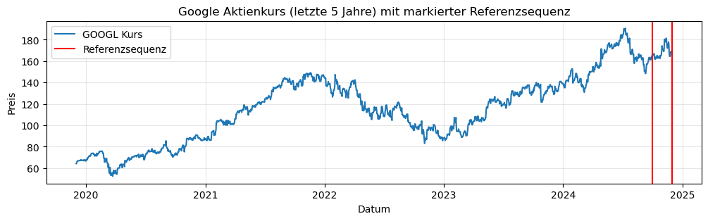

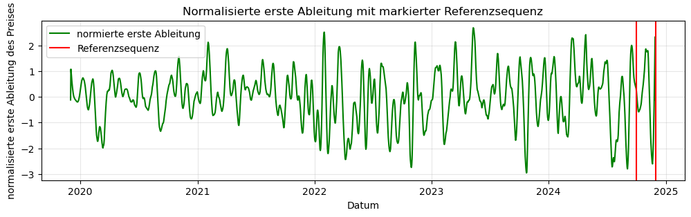

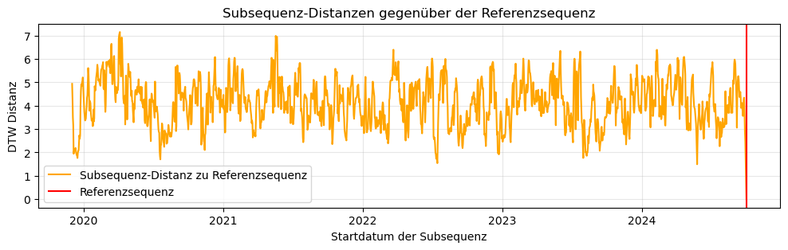

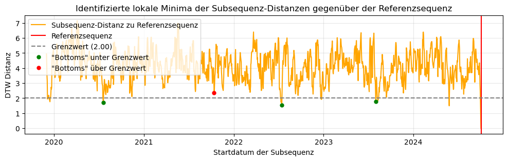

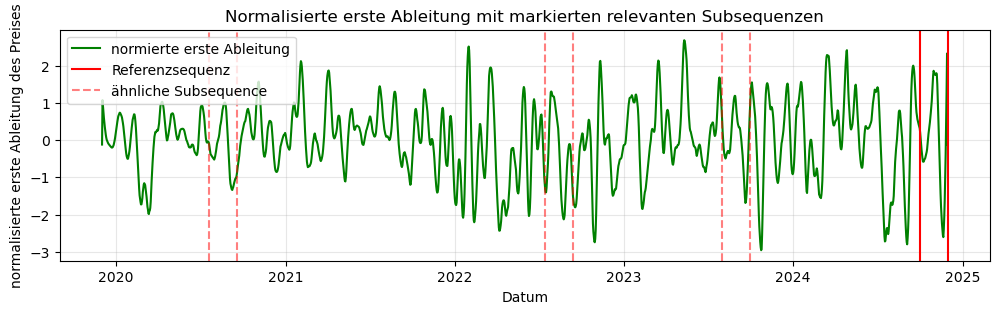

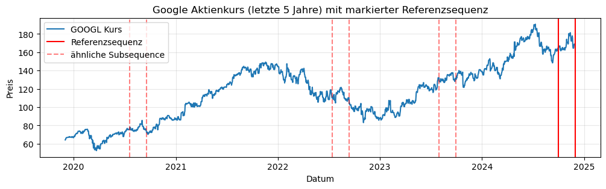

```python
google5yData = assets['tech']['GOOGL'][-5*365:]     # get the last 5 years of Google stock data
queryLength = 60                                    # length of the query sequence

# plot raw prices of Google stock for the last 5 years and mark the reference sequence
plt.figure(figsize=(12, 3))
plt.plot(dates[-5*365:], google5yData, label='GOOGL Kurs')
plt.title('Google Aktienkurs (letzte 5 Jahre) mit markierter Referenzsequenz')
plt.axvline(dates[-queryLength], color='red', linestyle='-', label='Referenzsequenz')
plt.axvline(dates[-1], color='red', linestyle='-')
plt.ylabel('Preis')
plt.xlabel('Datum')
plt.grid(alpha=0.3)
plt.legend()
plt.show()

# calculate the globale normalized derivatives of the last 5 years of Google stock data
google5ySmoothed = smoothTimeSeries(google5yData)
google5yDerivative = calculateDerivatives(smoothTimeSeries(google5ySmoothed))
google5yStdDerivative = standardizeData(google5yDerivative)

# plot normalized derivatives of the last 5 years of Google stock data with the reference sequence (only informational; for subsequence dtw calculation the normalization happens per subsequence)
plt.figure(figsize=(12, 3))
plt.plot(dates[-5*365:], google5yStdDerivative, color='green', label='normierte erste Ableitung')
plt.axvline(dates[-queryLength], color='red', linestyle='-', label='Referenzsequenz')
plt.axvline(dates[-1], color='red', linestyle='-')
plt.title('Normalisierte erste Ableitung mit markierter Referenzsequenz')
plt.ylabel('normalisierte erste Ableitung des Preises')
plt.xlabel('Datum')
plt.grid(alpha=0.3)
plt.legend()
plt.show()

# calculate the subsequence distances for the last 5 years of Google stock data
google5yDistances = calculateSubsequenceDistances(google5yData, windowSize=queryLength)

# plot the subsequence distances for the last 5 years of Google stock data
plt.figure(figsize=(12, 3))
plt.plot(dates[-5*365:-queryLength+1], google5yDistances, color='orange', label='Subsequenz-Distanz zu Referenzsequenz')
plt.axvline(dates[-queryLength+1], color='red', linestyle='-', label='Referenzsequenz')
plt.title('Subsequenz-Distanzen gegenüber der Referenzsequenz')
plt.ylabel('DTW Distanz')
plt.xlabel('Startdatum der Subsequenz')
plt.grid(alpha=0.3)
plt.legend()
plt.show()

# detect relevant bottoms of the subsequence distances for the last 5 years of Google stock data
google5yRelevantBottoms, google5yIrrelevantBottoms, google5yMinimaThreshold = getRelevantBottoms(google5yDistances, subsequenceWindow=queryLength)

# plot the subsequence distances for the last 5 years of Google stock data with detected relevant bottoms
plt.figure(figsize=(12, 3))
plt.plot(dates[-5*365:-queryLength+1], google5yDistances, color='orange', label='Subsequenz-Distanz zu Referenzsequenz')
plt.axvline(dates[-queryLength+1], color='red', linestyle='-', label='Referenzsequenz')
plt.axhline(y=google5yMinimaThreshold, color='gray', linestyle='--', label=f'Grenzwert ({google5yMinimaThreshold:.2f})')
plt.plot(dates[-5*365:][google5yRelevantBottoms[:, 1].astype(int)], google5yRelevantBottoms[:, 0], 'g.', label='"Bottoms" unter Grenzwert', markersize=10)
plt.plot(dates[-5*365:][google5yIrrelevantBottoms[:, 1].astype(int)], google5yIrrelevantBottoms[:, 0], 'r.', label='"Bottoms" über Grenzwert', markersize=10)
plt.title('Identifizierte lokale Minima der Subsequenz-Distanzen gegenüber der Referenzsequenz')
plt.ylabel('DTW Distanz')
plt.xlabel('Startdatum der Subsequenz')
plt.grid(alpha=0.3)
plt.legend(loc='upper left')
plt.show()

# plot found relevant subsequences and reference sequence of first derivative (only informational; for subsequence dtw calculation the normalization happens per subsequence)
plt.figure(figsize=(12, 3))
plt.plot(dates[-5*365:], google5yStdDerivative, color='green', label='normierte erste Ableitung')
plt.axvline(dates[-queryLength], color='red', linestyle='-', label='Referenzsequenz')
plt.axvline(dates[-1], color='red', linestyle='-')
plt.title('Normalisierte erste Ableitung mit markierten relevanten Subsequenzen')
plt.ylabel('normalisierte erste Ableitung des Preises')
for i, bottom in enumerate(google5yRelevantBottoms):
    plt.axvline(dates[-5*365:][int(bottom[1])], color='red', linestyle='--', alpha=0.5, label='ähnliche Subsequence' if i==0 else None)
    plt.axvline(dates[-5*365:][int(bottom[1])+queryLength], color='red', linestyle='--', alpha=0.5)
plt.xlabel('Datum')
plt.grid(alpha=0.3)
plt.legend()
plt.show()

# plot raw prices of Google stock for the last 5 years and mark the reference sequence and detected relevant subsequences
plt.figure(figsize=(12, 3))
plt.plot(dates[-5*365:], google5yData, label='GOOGL Kurs')
plt.title('Google Aktienkurs (letzte 5 Jahre) mit markierter Referenzsequenz')
plt.axvline(dates[-queryLength], color='red', linestyle='-', label='Referenzsequenz')
plt.axvline(dates[-1], color='red', linestyle='-')
for i, bottom in enumerate(google5yRelevantBottoms):
    plt.axvline(dates[-5*365:][int(bottom[1])], color='red', linestyle='--', alpha=0.5, label='ähnliche Subsequence' if i==0 else None)
    plt.axvline(dates[-5*365:][int(bottom[1])+queryLength], color='red', linestyle='--', alpha=0.5)
plt.ylabel('Preis')
plt.xlabel('Datum')
plt.grid(alpha=0.3)
plt.legend()
plt.show()
```

### 8.3. Prognosen anhand der identifizierten Subsequenzen

Anhand der identifizierten Subsequenzen sollen nun Prognosen für die zukünftige Kursentwicklung erstellt werden, die über das betrachtete Fenster der Subsequenz hinausgehen. Dies ermöglicht es, anschliessend die Genauigkeit dieser Prognosen zu bewerten. Da die vorgegebene Literatur zu diesem Thema keine spezifischen Empfehlungen gibt, basiert die nachfolgende Implementierung auf einem einfachen Ansatz, der nicht direkt an die Literatur angelehnt ist.

Hierfür werden die zuvor ermittelten ähnlichen Sequenzen verwendet, wobei der Endpreis jeder Sequenz mit dem Preis an einem bestimmten Tag x nach Ende der Sequenz verglichen wird. Die so berechneten, relativen Werte werden anschliessend aggregiert, indem der Durchschnitt, die Standardabweichung, der Median sowie die minimalen („Worst“) und maximalen („Best“) Werte ermittelt werden. Dieser Ansatz bietet einen Überblick über mögliche Kursentwicklungen basierend auf historischen Sequenzen und liefert wertvolle Einblicke in die potenziellen Schwankungen und Risiken.

```python
def predictTrends(timeseries, subsequenceEndIndexes, daysAhead):
    """
    Function to predict the trend of a time series based on the subsequences for a specific day after time series.

    Args:
        timeseries: time series data
        subsequenceEndIndexes: end indexes of the subsequences
        daysAhead: number of days after the subsequence end for which to predict

    Returns:
        avg: average trend prediction regarding historical data
        std: standard deviation of the trend prediction regarding historical data
        median: median trend prediction regarding historical data
        min: minimum trend prediction (worst case) regarding historical data
        max: maximum trend prediction (best case) regarding historical data
    """

    performances = [ ((timeseries[int(x)+daysAhead])/timeseries[int(x)])-1 for x in subsequenceEndIndexes ] # calculate the performance for each subsequence

    avg = np.mean(performances) # calculate the average performance
    std = np.std(performances) # calculate the standard deviation/volatility of the performance
    median = np.median(performances) # calculate the mean performance
    min = np.min(performances) # get the minimum performance
    max = np.max(performances) # get the maximum performance

    return avg,std,median,min,max
```

```python
# Define the days ahead for predictions
daysAheadToPredict = [1, 3, 7, 14, 30, 60, 90, 120, 150, 180]
print(f'Prognosen für {ASSET_TICKER} basierend auf den {len(relevantBottoms)} erkannten ähnlichen Sequenzen:')
# Calculate predictions for each day ahead
predictions = []
for daysAhead in daysAheadToPredict:
    avg, std, median, min_val, max_val = predictTrends(assets[ASSET_TYPE][ASSET_TICKER], relevantBottoms[:, 1], daysAhead)
    predictions.append({
        'Vorhersagezeitraum (Tage)': daysAhead,
        'Durchschnittliche Entwicklung': avg,
        'Standardabweichung': std,
        'Median': median,
        'Schlechtester Fall': min_val,
        'Bester Fall': max_val
    })
pd.DataFrame(predictions)
```

```
Prognosen für MSFT basierend auf den 9 erkannten ähnlichen Sequenzen:
```

|  | Vorhersagezeitraum (Tage) | Durchschnittliche Entwicklung | Standardabweichung | Median | Schlechtester Fall | Bester Fall |
| --- | --- | --- | --- | --- | --- | --- |
| 0 | 1 | 0.006531 | 0.016847 | 0.000000 | -0.009167 | 0.040221 |
| 1 | 3 | -0.013857 | 0.028127 | -0.011938 | -0.060763 | 0.040221 |
| 2 | 7 | -0.027653 | 0.026991 | -0.024852 | -0.063636 | 0.017035 |
| 3 | 14 | 0.036847 | 0.029276 | 0.034639 | -0.022917 | 0.081559 |
| 4 | 30 | 0.022805 | 0.057646 | 0.045085 | -0.080458 | 0.094542 |
| 5 | 60 | 0.030058 | 0.062656 | 0.055088 | -0.117242 | 0.106964 |
| 6 | 90 | 0.043007 | 0.088962 | 0.064115 | -0.180682 | 0.162085 |
| 7 | 120 | 0.082452 | 0.103226 | 0.104954 | -0.165499 | 0.235151 |
| 8 | 150 | 0.131139 | 0.148275 | 0.131386 | -0.237786 | 0.326683 |
| 9 | 180 | 0.161277 | 0.153698 | 0.200110 | -0.258178 | 0.312997 |

In der obenstehenden Tabelle werden die entsprechenden Kennzahlen für unterschiedliche Vorhersagezeiträume ermittelt und ausgegeben. Diese basieren auf der weiteren Entwicklung der Sequenzen, die als ähnlich zur Referenzsequenz gelten. Weitere Massnahmen zur Verbesserung der Vorhersagegenauigkeit, wie die Berücksichtigung zusätzlicher Signale, wurden bewusst nicht implementiert, da der Fokus dieser Arbeit ausschliesslich auf der Mustererkennung mit DTW liegt.

Es ist zu beachten, dass die Vorhersagen vollständig auf historischen Daten beruhen und daher fehleranfällig sind. Die Stabilität der Vorhersagen hängt massgeblich von der Anzahl an gefundenen ähnlichen Sequenzen ab. Eine grössere Anzahl ähnlicher historischer Situationen dürfte belastbarere Prognosen ermöglichen, während wenige gefundene Sequenzen die Vorhersagen potenziell instabil machen können.

Die Inhalte und Trends der Tabelle sind auf den ersten Blick schwer direkt zu erfassen. Ein Plot, basierend auf der zuvor definierten Funktion, bietet jedoch eine anschauliche Möglichkeit, die Informationen kompakt und übersichtlich darzustellen:

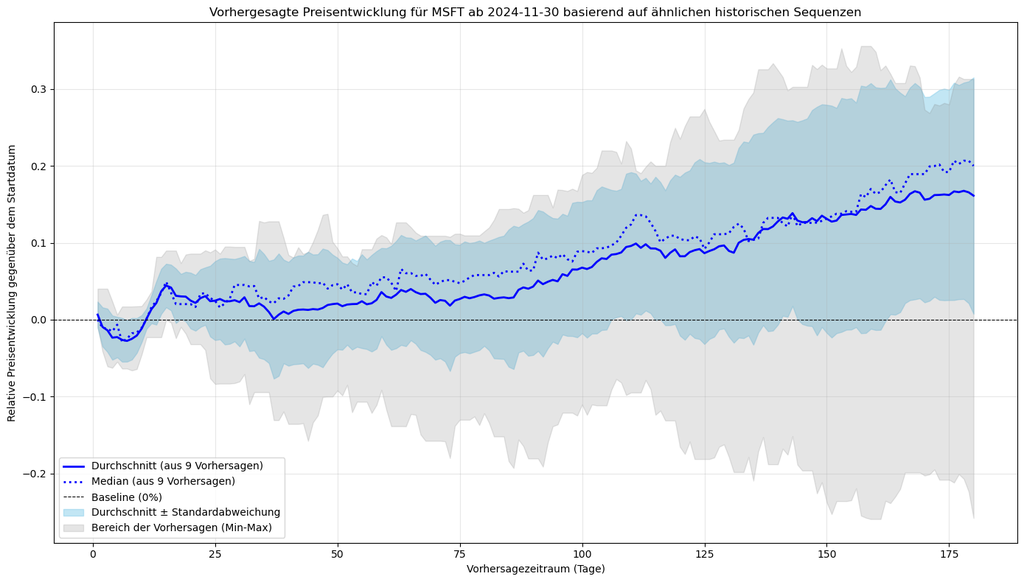

```python
# Generate predictions for 180 days
days = range(1, 181)
avgList, stdList, meanList, minList, maxList = [], [], [], [], []
for day in days:
    avg, std, median, min_val, max_val = predictTrends(assets[ASSET_TYPE][ASSET_TICKER], relevantBottoms[:, 1], day)
    avgList.append(avg)
    stdList.append(std)
    meanList.append(median)
    minList.append(min_val)
    maxList.append(max_val)

plt.figure(figsize=(14, 8))

# Plot the predictions
plt.plot(days, avgList, color='blue', linewidth=2, linestyle='-', label=f'Durchschnitt (aus {len(relevantBottoms)} Vorhersagen)')
plt.plot(days, meanList, color='blue', linewidth=2, linestyle=':', label=f'Median (aus {len(relevantBottoms)} Vorhersagen)')
plt.axhline(0, color='black', linewidth=0.8, linestyle='--', label='Baseline (0%)')

# Fill the area between the average and the standard deviation and between the min and max values
plt.fill_between(days, np.array(avgList) - np.array(stdList), np.array(avgList) + np.array(stdList),color='skyblue', alpha=0.5, label='Durchschnitt ± Standardabweichung')
plt.fill_between(days, minList, maxList, color='grey', alpha=0.2, label='Bereich der Vorhersagen (Min-Max)')

plt.title(f'Vorhergesagte Preisentwicklung für {ASSET_TICKER} ab {END_DATE} basierend auf ähnlichen historischen Sequenzen')
plt.xlabel('Vorhersagezeitraum (Tage)')
plt.ylabel('Relative Preisentwicklung gegenüber dem Startdatum')
plt.legend(loc='lower left')
plt.grid(alpha=0.3)

plt.tight_layout()
plt.show()
```

Die Grafik zeigt die Kursprognose in Form der prozentualen Veränderung gegenüber dem Ausgangspreis für die nächsten 180 Tage, basierend auf 9 ähnlichen Sequenzen der letzten 15 Jahre, die der Referenzsequenz von Ende August bis Ende November 2024 ähneln.

In vergleichbaren historischen Sequenzen wurden innerhalb von 180 Tagen maximal Verluste von rund 25 % beobachtet. Dies weist auf ein erhöhtes Risiko bei langfristigen Prognosen hin. Eine konservative Anlagestrategie könnte durch die Verwendung von Stop-Loss-Limits mögliche Verluste begrenzen. Gleichzeitig ist aber wie bereits erwähnt, der langfristige Trend bei den meisten beobachteten ähnlichen Sequenzen deutlich positiv. Dieser Aufwärtstrend, kombiniert mit der relativ grossen Unsicherheitsbandbreite, legt nahe, dass Zukäufe besonders für Anleger mit einer längeren Haltedauer und einer höheren Risikobereitschaft sinnvoll sein könnten.

## 9. DTW Anwendung: Handelssignale

Abschliessend werden die entwickelten Mechanismen und Analysen auf ihre praktische Anwendbarkeit geprüft. Ziel ist es zu bewerten, ob die Mustererkennung mittels subsequence DDTW und die daraus abgeleiteten Prognosen zur Generierung sinnvoller Handelssignale eingesetzt werden können. Dabei wird bewusst jeweils nur ein einzelnes Asset betrachtet, da der Fokus auf der Analyse einer einzelnen Zeitreihe liegt und nicht auf einem Portfolio und der Allokation innerhalb eines solchen. Diese Einschränkung ermöglicht eine präzisere Bewertung des Nutzens von DTW für die Mustererkennung, was den primären Zweck dieser Arbeit unterstützt. Sie reduziert diesbezüglich die Anzahl zusätzlicher Parameter sowie die Variabilität, die durch die Verwaltung eines Portfolios entstehen und die Kernerkenntnisse verfälschen könnten.

### 9.1. Vorbereitungen und Hilfsfunktionen für Einsatz von Backtrader

Für die Evaluation wird die verbreitete Backtrader-Bibliothek eingesetzt. Erste Tests zeigen, dass Anpassungen erforderlich sind, um die Bibliothek in der aktuellen Umgebung lauffähig zu machen. Um die Komplexität der Dynamic Time Warping (DTW) in einer ersten Phase auszuklammern und die grundlegende Funktionalität von Backtrader zu validieren, wird zunächst eine einfache Strategie basierend auf den Kreuzungen des kurzfristigen und langfristigen gleitenden Durchschnitts getestet. Ziel ist es, die Funktionalität und Plausibilität der Ergebnisse zu überprüfen, sich mit Backtrader vertraut zu machen, sowie geeignete Kennzahlen für die spätere Analyse zu identifizieren.

```python
# add generic reusable function to convert asset time series data to backtrader data format
def convertAssetToBTData(assetTimeSeries, assetDates=None):
    '''
    Function to convert asset time series data to backtrader data format.

    Args:
        assetTimeSeries: asset time series data
        assetDates: asset dates data (default is None --> use default dates)

    Returns:
        bt.feeds.PandasData: backtrader data feed
    '''
    if assetDates is None: # if no dates are provided, use the default range
        assetDates = dates

    if len(assetDates) != len(assetTimeSeries):
        raise ValueError('Length of assetDates (or default dates if not provided) and assetTimeSeries must be the same.')

    # prepare the data frame for backtrader
    data = pd.DataFrame({
            'datetime': assetDates,
            'close': assetTimeSeries, # use the closing prices as the main price for trading
            'volume': np.zeros_like(assetTimeSeries), # no volume data available --> set to zero to prevent plotting errors
    })
    data.set_index('datetime', inplace=True)

    # convert the data to backtrader format
    return bt.feeds.PandasData(dataname=data)

# add function to plot the cerebro object in a Jupyter notebook
def plotBTFigures(figures):
    """
    Workaround function to plot the cerebro object in a Jupyter notebook (to resolve issues regarding missing plot output when plotting multiple figures).

    Args:
        figures: figure object to plot
    """
    figures[0][0].savefig('tmp.png')
    ipd.display(ipd.Image('tmp.png'))
    os.remove('tmp.png')

# add function to get average risk-free rate for a given time period for caluclating the Sharpe ratio
def getAverageRiskfreeRate(startDate, endDate):
    """
    Function to get the average risk-free rate for a given time period (based on the 10-year US Treasury yield, ^TNX).

    Args:
        startDate: start date of the time period
        endDate: end date of the time period

    Returns:
        rfRate: average risk-free rate for the time period
    """

    # get the risk-free rate data for the given time period
    riskfree_rate_data = yf.download('^TNX', start=str(startDate), end=str(endDate),progress=False)['Close']

    # calculate the average risk-free rate
    rfRate = np.mean(riskfree_rate_data) / 100.0 # convert percentage to decimal

    return rfRate

# add function to create a empty dataframe for storing the backtest results
def createResultsDF():
    '''
    Function to create a dataframe for storing the backtest results.

    Returns:
        results: empty dataframe for storing the backtest results
    '''
    categories = {
        "Fundamentals": [
            "Starting Portfolio Value",
            "Final Portfolio Value",
            "Net Profit",
            "Profit (%)",
            "Annualized Return (%)",
            "Max Drawdown (%)",
            "Calmar Ratio",
            "Sharpe Ratio"
        ],
        "Activity": [
            "Total Trades",
            "Winning Trades",
            "Losing Trades"
        ],
        "Trade quality": [
            "Hit Rate (%)",
            "Profit Factor",
            "Average Win",
            "Average Loss"
        ]
    }
    rows = [{"Category": category, "Metric": metric} for category, metrics in categories.items() for metric in metrics]
    return pd.DataFrame(rows)

# add function to add summary columns (avg + std) to the results dataframe
def addSummaryColumnsToDF(resultsDF):
    '''
    Function to add summary columns (average and standard deviation) to the results dataframe.

    Args:
        resultsDF: dataframe containing the backtest results

    Returns:
        resultsDF: dataframe with added summary columns
    '''
    # Add columns for average and standard deviation of metrics
    numeric_cols = resultsDF.select_dtypes(include=['number'])
    resultsDF['Average'] = numeric_cols.mean(axis=1).round(2)
    resultsDF['Standard Deviation'] = numeric_cols.std(axis=1).round(2)
    return resultsDF

# add function to calculate metrics for the backtests execution
def calculateBacktestMetrics(startValue, endValue, numberOfDays, drawdownAnalyzer, sharpeAnalyzer, tradeAnalyzer):
    '''
    Function to calculate the metrics of a backtest execution.

    Args:
        startValue: starting portfolio value
        endValue: final portfolio value
        numberOfDays: number of days for the backtest
        drawdownAnalyzer: drawdown analyzer object
        sharpeAnalyzer: sharpe ratio analyzer object
        tradeAnalyzer: trade analyzer object

    Returns:
        metrics: calculated backtest metrics
    '''
    # fundamental metrics
    netProfit = endValue - startValue
    profitPercentage = (netProfit / startValue) * 100
    annualizedReturn = ((endValue / startValue) ** (365 / numberOfDays)) - 1
    maxDrawdown = drawdownAnalyzer.get_analysis().get('max', {}).get('drawdown', 0) / 100
    sharpeRatio = sharpeAnalyzer.get_analysis().get('sharperatio', None)
    calmarRatio = (annualizedReturn / abs(maxDrawdown)) if maxDrawdown != 0 else float('inf')

    # activity metrics
    totalTrades = tradeAnalyzer.total.get('total', 0)
    winningTrades = tradeAnalyzer.won.get('total', 0) if 'won' in tradeAnalyzer else 0
    losingTrades = tradeAnalyzer.lost.get('total', 0) if 'lost' in tradeAnalyzer else 0

    # trade quality metrics
    hitRate = (winningTrades / totalTrades * 100) if totalTrades > 0 else 0
    profitFactor = ((tradeAnalyzer.won.pnl.total / abs(tradeAnalyzer.lost.pnl.total) if tradeAnalyzer.lost.pnl.total != 0 else float('inf'))) if winningTrades+losingTrades > 0 else 0
    avgWin = tradeAnalyzer.won.pnl.average if winningTrades > 0 else 0
    avgLoss = tradeAnalyzer.lost.pnl.average if losingTrades > 0 else 0

    return {
        "Starting Portfolio Value": startValue,
        "Final Portfolio Value": endValue,
        "Net Profit": netProfit,
        "Profit (%)": profitPercentage,
        "Annualized Return (%)": annualizedReturn * 100,
        "Max Drawdown (%)": maxDrawdown * 100,
        "Calmar Ratio": calmarRatio,
        "Sharpe Ratio": sharpeRatio,
        "Total Trades": totalTrades,
        "Winning Trades": winningTrades,
        "Losing Trades": losingTrades,
        "Hit Rate (%)": hitRate,
        "Profit Factor": profitFactor,
        "Average Win": avgWin,
        "Average Loss": avgLoss
    }

# add function to run a backtest with a given asset, strategy, and time range
def runBacktest(title, asset, strategy, strategyArgs={}, timeRange=None, riskFreeRate=None, noTransactionLog=False, noPlot=False):
    '''
    Function to run a backtest with a given asset, strategy, and time range.

    Args:
        title: title of the asset
        asset: asset data
        strategy: strategy to use for the backtest
        strategyArgs: arguments for the strategy
        timeRange: time range for the backtest
        riskFreeRate: risk-free rate for the backtest
        noTransactionLog: flag to disable transaction log output
        noPlot: flag to disable plot output
    Returns:
        metrics: calculated backtest metrics
    '''
    # if no time range is provided, use the full available data
    if timeRange is None:
        timeRange = len(dates)

    # if no risk-free rate is provided, calculate the average risk-free rate for the time period
    if riskFreeRate is None:
        riskFreeRate = getAverageRiskfreeRate(dates[-timeRange], dates[-1])

    # initializing the backtesting engine
    cerebro = bt.Cerebro()
    cerebro.broker.setcommission(commission=0.001)      # set the commission for trading to penalize overly frequent trading
    cerebro.broker.set_coc(True)                        # set the close-on-commission flag to True to close the position on the same day as the order execution --> uses closing prices for trading (as we only use closing prices for dtw), no intra-day trading

    # add the asset data to the backtesting engine
    cerebro.adddata(convertAssetToBTData(asset[-timeRange:],dates[-timeRange:]), name=title)

    # prepare and add the strategy to the backtesting engine
    if noTransactionLog: strategyArgs['quiet'] = True
    else: strategyArgs['quiet'] = False

    cerebro.addstrategy(strategy, **strategyArgs)

    # add analyzers to the backtesting engine to allow strategy performance analysis
    cerebro.addanalyzer(bt.analyzers.SharpeRatio, _name='sharpe', riskfreerate=riskFreeRate)
    cerebro.addanalyzer(bt.analyzers.DrawDown, _name='drawdown')
    cerebro.addanalyzer(bt.analyzers.TradeAnalyzer, _name='trades')

    # run backtesting
    startValue = cerebro.broker.getvalue()
    if not noTransactionLog: print(f'Transaction log:\n{"="*16}')
    results = cerebro.run()
    endValue = cerebro.broker.getvalue()

    # plot results if not disabled
    if not noPlot:
        plt.rcParams['figure.figsize'] = [16, 9]
        plotBTFigures(cerebro.plot(style='line')) # use 'line' style as we only use the closing prices for trading based on dtw and 'candle' style would not be meaningful (without open, high, low prices)

    # calculate and return the backtest metrics
    return calculateBacktestMetrics(startValue, endValue, timeRange, results[0].analyzers.drawdown, results[0].analyzers.sharpe, results[0].analyzers.trades.get_analysis())
```

```python
# custom strategy class for moving average crossover strategy
class MovingAverageCrossoverStrategy(bt.Strategy):
    params = (
        ('shortPeriod', 25),  # days for the short-term MA
        ('longPeriod', 100),   # days for the long-term MA
        ('cash', .99),        # percentage of cash to use for trading (prefered over using fixed number of shares to improve comparability between different assets on different price levels) --> keep 1% cash for commissions to make sure trades are executed
        ('quiet', False)      # flag to suppress output
    )

    def __init__(self):
        # Calculate moving averages
        self.shortMA = bt.indicators.SimpleMovingAverage(self.datas[0].close, period=self.params.shortPeriod)
        self.longMA = bt.indicators.SimpleMovingAverage(self.datas[0].close, period=self.params.longPeriod)

    def next(self):
        # Ensure enough data is available for the long MA
        if len(self.datas[0]) < self.params.longPeriod:
            return

        # Buy signal: Short MA crosses above long MA
        if self.shortMA[0] > self.longMA[0] and self.shortMA[-1] <= self.longMA[-1]:
            if not self.position:  # Only buy if no existing position
                self.buy(size=self.broker.get_cash() * self.params.cash / self.datas[0].close[0])
                if not self.params.quiet: print(f"  - {self.datas[0].datetime.date(0)}: Buy - Short MA kreuzt über Long MA bei {self.datas[0].close[0]}")

        # Sell signal: Short MA crosses below long MA
        elif self.shortMA[0] < self.longMA[0] and self.shortMA[-1] >= self.longMA[-1]:
            if self.position.size > 0:  # Only sell if a position is open
                self.sell(size=self.position.size)  # Sell the entire position
                if not self.params.quiet: print(f"  - {self.datas[0].datetime.date(0)}: Sell - Short MA kreuzt unter Long MA bei {self.datas[0].close[0]}")
```

```
Transaction log:
================
  - 2020-04-23: Buy - Short MA kreuzt über Long MA bei 164.4085693359375
  - 2020-09-26: Sell - Short MA kreuzt unter Long MA bei 200.35801696777344
  - 2020-10-15: Buy - Short MA kreuzt über Long MA bei 211.77291870117188
  - 2022-01-16: Sell - Short MA kreuzt unter Long MA bei 302.35833740234375
  - 2022-04-07: Buy - Short MA kreuzt über Long MA bei 294.3589172363281
  - 2022-04-20: Sell - Short MA kreuzt unter Long MA bei 279.6981201171875
  - 2022-08-03: Buy - Short MA kreuzt über Long MA bei 276.5412292480469
  - 2022-09-13: Sell - Short MA kreuzt unter Long MA bei 247.224609375
  - 2022-12-02: Buy - Short MA kreuzt über Long MA bei 250.9024200439453
  - 2023-01-07: Sell - Short MA kreuzt unter Long MA bei 221.2982635498047
  - 2023-02-01: Buy - Short MA kreuzt über Long MA bei 248.66908264160156
  - 2023-08-15: Sell - Short MA kreuzt unter Long MA bei 318.15032958984375
  - 2023-10-26: Buy - Short MA kreuzt über Long MA bei 324.7970275878906
  - 2024-04-30: Sell - Short MA kreuzt unter Long MA bei 387.15484619140625
  - 2024-05-24: Buy - Short MA kreuzt über Long MA bei 428.5283203125
  - 2024-08-05: Sell - Short MA kreuzt unter Long MA bei 393.6510925292969
  - 2024-10-03: Buy - Short MA kreuzt über Long MA bei 415.7079162597656
  - 2024-10-12: Sell - Short MA kreuzt unter Long MA bei 415.48834228515625
  - 2024-10-28: Buy - Short MA kreuzt über Long MA bei 425.7378234863281
  - 2024-11-19: Sell - Short MA kreuzt unter Long MA bei 416.9554138183594
```

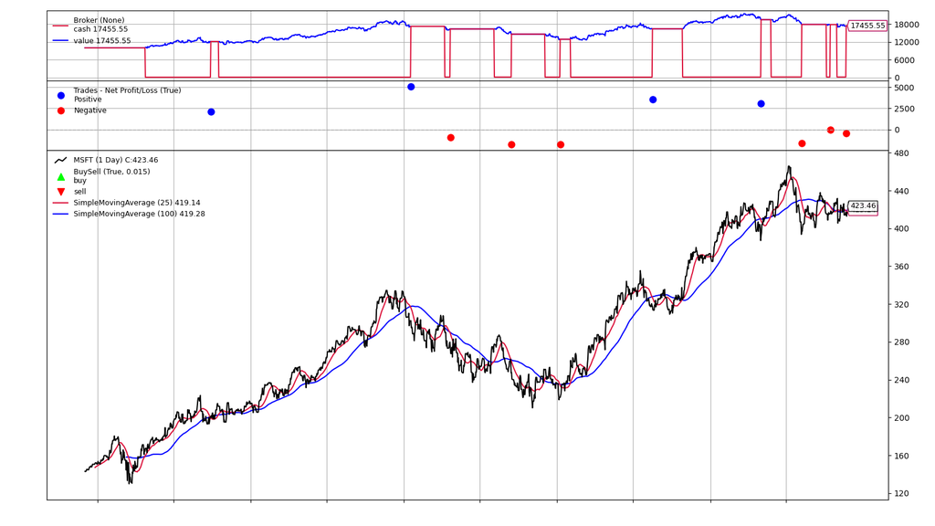

|  | Category | Metric | MSFT |
| --- | --- | --- | --- |
| 0 | Fundamentals | Starting Portfolio Value | 10000.00 |
| 1 | Fundamentals | Final Portfolio Value | 17455.55 |
| 2 | Fundamentals | Net Profit | 7455.55 |
| 3 | Fundamentals | Profit (%) | 74.56 |
| 4 | Fundamentals | Annualized Return (%) | 11.79 |
| 5 | Fundamentals | Max Drawdown (%) | 34.12 |
| 6 | Fundamentals | Calmar Ratio | 0.35 |
| 7 | Fundamentals | Sharpe Ratio | 0.39 |
| 8 | Activity | Total Trades | 10.00 |
| 9 | Activity | Winning Trades | 4.00 |
| 10 | Activity | Losing Trades | 6.00 |
| 11 | Trade quality | Hit Rate (%) | 40.00 |
| 12 | Trade quality | Profit Factor | 2.16 |
| 13 | Trade quality | Average Win | 3469.34 |
| 14 | Trade quality | Average Loss | -1070.30 |

```python
# single asset analysis for MSFT including transaction log an plot
resultsDF = createResultsDF()
resultsDF['MSFT'] = resultsDF['Metric'].map(runBacktest('MSFT', assets['tech']['MSFT'], MovingAverageCrossoverStrategy, timeRange=5*365)).round(2)
ipd.display(resultsDF)
```

Mit den zuvor definierten Funktionen zur Simulation und Analyse von Handelsstrategien und der Integration von Backtrader unter Verwendung der einfachen MovingAverageCrossoverStrategy lässt sich der Handel mit dieser Strategie für ein einzelnes Asset simulieren. Die Simulation ermöglicht die Ausgabe des Transaktionsprotokolls, die Visualisierung des zeitlichen Verlaufs sowie die Berechnung relevanter Metriken, wie Annualized Return, Max Drawdown und Sharpe Ratio, um den Erfolg der Strategie zu bewerten. Dabei ist zu beachten, dass die Analyse auf ein einzelnes Asset beschränkt ist, wodurch die Aussagekraft der Ergebnisse aufgrund der geringen Stichprobenmenge und die dadurch fehlende Robustheit der Ergebnisse eingeschränkt bleibt.

```python
# comperative asset analysis for all fetched assets for MovingAverageCrossoverStrategy (transaction log and plot disabled for better readability --> only show results table)
resultsDF = createResultsDF()
riskFreeRate = getAverageRiskfreeRate(dates[-5*365], dates[-1]) # calculate the average risk-free rate for the last 5 years based on 10-year US Treasury yield to use it for all assetes (even if the assets are traded abroad --> allows better comparability for the Sharpe ratio for the different assets)
for assetType in assets.keys():
    for ticker in assets[assetType].keys():
        print(f"Running backtest simulation for {ticker} ({assetType})...")
        resultsDF[ticker] = resultsDF['Metric'].map(runBacktest(ticker, assets[assetType][ticker], MovingAverageCrossoverStrategy, timeRange=5*365, riskFreeRate=riskFreeRate, noTransactionLog=True, noPlot=True)).round(2)

# add summary columns to the results dataframe
resultsDF = addSummaryColumnsToDF(resultsDF)

print("\n\nResults for MovingAverageCrossoverStrategy:")
ipd.display(resultsDF)
```

```
Running backtest simulation for AAPL (tech)...
Running backtest simulation for MSFT (tech)...
Running backtest simulation for GOOGL (tech)...
Running backtest simulation for NESN.SW (consumer_staples)...
Running backtest simulation for PG (consumer_staples)...
Running backtest simulation for UL (consumer_staples)...
Running backtest simulation for ABBN.SW (industrial)...
Running backtest simulation for SIEGY (industrial)...
Running backtest simulation for GE (industrial)...
Running backtest simulation for GC=F (precious_metals)...
Running backtest simulation for SI=F (precious_metals)...
Running backtest simulation for PL=F (precious_metals)...
Running backtest simulation for ^SSMI (market_indexes)...
Running backtest simulation for ^GDAXI (market_indexes)...
Running backtest simulation for ^GSPC (market_indexes)...


Results for MovingAverageCrossoverStrategy:
```

|  | Category | Metric | AAPL | MSFT | GOOGL | NESN.SW | PG | UL | ABBN.SW | SIEGY | GE | GC=F | SI=F | PL=F | ^SSMI | ^GDAXI | ^GSPC | Average | Standard Deviation |
| --- | --- | --- | --- | --- | --- | --- | --- | --- | --- | --- | --- | --- | --- | --- | --- | --- | --- | --- | --- |
| 0 | Fundamentals | Starting Portfolio Value | 10000.00 | 10000.00 | 10000.00 | 10000.00 | 10000.00 | 10000.00 | 10000.00 | 10000.00 | 10000.00 | 10000.00 | 10000.00 | 10000.00 | 10000.00 | 10000.00 | 10000.00 | 10000.00 | 0.00 |
| 1 | Fundamentals | Final Portfolio Value | 21401.83 | 17455.55 | 19903.17 | 8951.51 | 11055.45 | 11174.89 | 24150.90 | 20500.68 | 39698.76 | 13207.16 | 10403.78 | 10524.23 | 8835.10 | 13750.19 | 15661.78 | 16445.00 | 8083.99 |
| 2 | Fundamentals | Net Profit | 11401.83 | 7455.55 | 9903.17 | -1048.49 | 1055.45 | 1174.89 | 14150.90 | 10500.68 | 29698.76 | 3207.16 | 403.78 | 524.23 | -1164.90 | 3750.19 | 5661.78 | 6445.00 | 8083.99 |
| 3 | Fundamentals | Profit (%) | 114.02 | 74.56 | 99.03 | -10.48 | 10.55 | 11.75 | 141.51 | 105.01 | 296.99 | 32.07 | 4.04 | 5.24 | -11.65 | 37.50 | 56.62 | 64.45 | 80.84 |
| 4 | Fundamentals | Annualized Return (%) | 16.44 | 11.79 | 14.76 | -2.19 | 2.03 | 2.25 | 19.29 | 15.44 | 31.75 | 5.72 | 0.79 | 1.03 | -2.45 | 6.58 | 9.39 | 8.84 | 9.48 |
| 5 | Fundamentals | Max Drawdown (%) | 22.74 | 34.12 | 28.66 | 30.66 | 27.24 | 22.81 | 18.68 | 26.60 | 29.35 | 17.29 | 44.25 | 24.25 | 27.78 | 22.64 | 24.99 | 26.80 | 6.55 |
| 6 | Fundamentals | Calmar Ratio | 0.72 | 0.35 | 0.51 | -0.07 | 0.07 | 0.10 | 1.03 | 0.58 | 1.08 | 0.33 | 0.02 | 0.04 | -0.09 | 0.29 | 0.38 | 0.36 | 0.37 |
| 7 | Fundamentals | Sharpe Ratio | 0.47 | 0.39 | 0.47 | -0.30 | -0.01 | -0.06 | 0.74 | 0.61 | 0.82 | 0.30 | -0.02 | -0.10 | -0.37 | 0.30 | 0.39 | 0.24 | 0.37 |
| 8 | Activity | Total Trades | 12.00 | 10.00 | 9.00 | 9.00 | 13.00 | 12.00 | 8.00 | 12.00 | 9.00 | 11.00 | 14.00 | 9.00 | 11.00 | 11.00 | 10.00 | 10.67 | 1.72 |
| 9 | Activity | Winning Trades | 6.00 | 4.00 | 4.00 | 2.00 | 6.00 | 4.00 | 6.00 | 5.00 | 4.00 | 6.00 | 5.00 | 3.00 | 4.00 | 4.00 | 4.00 | 4.47 | 1.19 |
| 10 | Activity | Losing Trades | 5.00 | 6.00 | 4.00 | 7.00 | 7.00 | 8.00 | 1.00 | 6.00 | 4.00 | 4.00 | 9.00 | 6.00 | 7.00 | 6.00 | 5.00 | 5.67 | 1.95 |
| 11 | Trade quality | Hit Rate (%) | 50.00 | 40.00 | 44.44 | 22.22 | 46.15 | 33.33 | 75.00 | 41.67 | 44.44 | 54.55 | 35.71 | 33.33 | 36.36 | 36.36 | 40.00 | 42.24 | 11.93 |
| 12 | Trade quality | Profit Factor | 4.46 | 2.16 | 3.73 | 0.63 | 1.32 | 1.45 | 10.89 | 2.96 | 7.37 | 2.88 | 1.08 | 1.18 | 0.62 | 1.80 | 2.66 | 3.01 | 2.80 |
| 13 | Trade quality | Average Win | 2408.35 | 3469.34 | 3236.86 | 904.36 | 731.99 | 948.30 | 2502.63 | 3478.06 | 8503.60 | 517.42 | 1155.39 | 1126.09 | 467.97 | 1841.62 | 1864.08 | 2210.40 | 2033.75 |
| 14 | Trade quality | Average Loss | -648.36 | -1070.30 | -867.47 | -408.17 | -476.64 | -327.29 | -1379.44 | -977.99 | -1153.40 | -269.63 | -597.02 | -475.68 | -433.83 | -683.81 | -560.81 | -688.66 | 329.61 |

Mit den implementierten Funktionen ist es zudem möglich, wie zuvor gezeigt, mehrere Simulationsläufe über unterschiedliche Assets durchzuführen, tabellarisch zusammenzufassen und zu analysieren. Dies ermöglicht eine breiter abgestützte Beurteilung der Qualität einer Strategie. Die obenstehend generierte Tabelle, basierend auf der MovingAverageCrossoverStrategy(25,100) (aufgrund ihrer Einfachheit und Verbreitung), dient als Performancereferenz für die im nächsten Unterkapitel entwickelte Subsequence-DDTW-Strategie.

Ergänzend dazu sollen zwei weitere Tabellen auf Basis einfacher Handelsstrategien als zusätzliche Performancereferenzen berechnet werden:

- Erstens wird eine klassische Buy-and-Hold-Strategie mit einer einzigen Kauforder zu Beginn des Simulationsfensters betrachtet, um die reine Asset-Performance über die fünf simulierten Jahre zu bewerten.
- Zweitens wird eine weitere Cost-Averaging-Strategie umgesetzt, bei der monatlich gleich grosse Beträge investiert werden. Diese Methode verringert die Relevanz des Einsteigezeitpunkts, da die Käufe über den Zeitraum verteilt sind. Sie entspricht einer häufig empfohlenen Investitionsstrategie für den Vermögensaufbau, wobei zu beachten ist, dass im Durchschnitt über den ganzen Investitionszeitraum nur rund 50 % des Vermögens investiert sind, was die erwartete Performance beeinflusst.

```python
# custom strategy class for buy and hold strategy
class BuyAndHoldStrategy(bt.Strategy):
    params = (
        ('cash', .99),        # percentage of cash to use for trading (prefered over using fixed number of shares to improve comparability between different assets on different price levels) --> keep 1% cash for commissions to make sure trades are executed
        ('quiet', False)      # flag to suppress output
    )

    def __init__(self):
        self.firstBuy = False # flag to indicate the first buy

    def next(self):
        if not self.firstBuy:
            size=self.broker.get_cash() * self.params.cash / self.datas[0].close[0]
            self.buy(size=size)
            self.firstBuy = True
            if not self.params.quiet: print(f"  - {self.datas[0].datetime.date(0)}: Buy - First trading day at {self.datas[0].close[0]} --> buy {size:.2f} shares")

# comperative asset analysis for all fetched assets for BuyAndHoldStrategy (transaction log and plot disabled for better readability --> only show results table)
resultsDF = createResultsDF()
riskFreeRate = getAverageRiskfreeRate(dates[-5*365], dates[-1]) # calculate the average risk-free rate for the last 5 years based on 10-year US Treasury yield to use it for all assetes (even if the assets are traded abroad --> allows better comparability for the Sharpe ratio for the different assets)
for assetType in assets.keys():
    for ticker in assets[assetType].keys():
        print(f"Running backtest simulation for {ticker} ({assetType})...")
        resultsDF[ticker] = resultsDF['Metric'].map(runBacktest(ticker, assets[assetType][ticker], BuyAndHoldStrategy, timeRange=5*365, riskFreeRate=riskFreeRate, noTransactionLog=True, noPlot=True)).round(2)

# add summary columns to the results dataframe
resultsDF = addSummaryColumnsToDF(resultsDF)

# show only the fundamental metrics for better readability, as the activity and trade quality metrics are not meaningful for the BuyAndHoldStrategy
resultsDF = resultsDF.iloc[:8]

print("\n\nResults for BuyAndHoldStrategy:")
ipd.display(resultsDF)
```

```
Running backtest simulation for AAPL (tech)...
Running backtest simulation for MSFT (tech)...
Running backtest simulation for GOOGL (tech)...
Running backtest simulation for NESN.SW (consumer_staples)...
Running backtest simulation for PG (consumer_staples)...
Running backtest simulation for UL (consumer_staples)...
Running backtest simulation for ABBN.SW (industrial)...
Running backtest simulation for SIEGY (industrial)...
Running backtest simulation for GE (industrial)...
Running backtest simulation for GC=F (precious_metals)...
Running backtest simulation for SI=F (precious_metals)...
Running backtest simulation for PL=F (precious_metals)...
Running backtest simulation for ^SSMI (market_indexes)...
Running backtest simulation for ^GDAXI (market_indexes)...
Running backtest simulation for ^GSPC (market_indexes)...


Results for BuyAndHoldStrategy:
```

|  | Category | Metric | AAPL | MSFT | GOOGL | NESN.SW | PG | UL | ABBN.SW | SIEGY | GE | GC=F | SI=F | PL=F | ^SSMI | ^GDAXI | ^GSPC | Average | Standard Deviation |
| --- | --- | --- | --- | --- | --- | --- | --- | --- | --- | --- | --- | --- | --- | --- | --- | --- | --- | --- | --- |
| 0 | Fundamentals | Starting Portfolio Value | 10000.00 | 10000.00 | 10000.00 | 10000.00 | 10000.00 | 10000.00 | 10000.00 | 10000.00 | 10000.00 | 10000.00 | 10000.00 | 10000.00 | 10000.00 | 10000.00 | 10000.00 | 10000.00 | 0.00 |
| 1 | Fundamentals | Final Portfolio Value | 36787.95 | 29397.87 | 26109.16 | 8513.77 | 16450.90 | 11997.70 | 28844.57 | 17352.81 | 33212.21 | 18078.41 | 18133.67 | 10566.03 | 11344.51 | 15077.11 | 19268.99 | 20075.71 | 8748.94 |
| 2 | Fundamentals | Net Profit | 26787.95 | 19397.87 | 16109.16 | -1486.23 | 6450.90 | 1997.70 | 18844.57 | 7352.81 | 23212.21 | 8078.41 | 8133.67 | 566.03 | 1344.51 | 5077.11 | 9268.99 | 10075.71 | 8748.94 |
| 3 | Fundamentals | Profit (%) | 267.88 | 193.98 | 161.09 | -14.86 | 64.51 | 19.98 | 188.45 | 73.53 | 232.12 | 80.78 | 81.34 | 5.66 | 13.45 | 50.77 | 92.69 | 100.76 | 87.49 |
| 4 | Fundamentals | Annualized Return (%) | 29.76 | 24.07 | 21.16 | -3.17 | 10.47 | 3.71 | 23.60 | 11.65 | 27.13 | 12.57 | 12.64 | 1.11 | 2.56 | 8.56 | 14.02 | 13.32 | 10.03 |
| 5 | Fundamentals | Max Drawdown (%) | 31.20 | 37.00 | 44.15 | 36.28 | 23.62 | 27.45 | 38.60 | 48.68 | 57.80 | 20.74 | 40.09 | 41.27 | 27.32 | 38.45 | 33.64 | 36.42 | 9.71 |
| 6 | Fundamentals | Calmar Ratio | 0.95 | 0.65 | 0.48 | -0.09 | 0.44 | 0.14 | 0.61 | 0.24 | 0.47 | 0.61 | 0.32 | 0.03 | 0.09 | 0.22 | 0.42 | 0.37 | 0.28 |
| 7 | Fundamentals | Sharpe Ratio | 0.79 | 0.70 | 0.59 | -0.30 | 0.58 | 0.09 | 0.86 | 0.47 | 0.61 | 0.69 | 0.48 | -0.15 | 0.01 | 0.45 | 0.62 | 0.43 | 0.35 |

```python
# custom strategy class for buy and hold strategy
class CostAveragingStrategy(bt.Strategy):
    params = (
        ("investmentPerMonth", 1000),     # investment per month
        ('quiet', False)                    # flag to suppress output
    )

    def __init__(self):
        self.nextInvestmentDate = None

    def next(self):
        if self.nextInvestmentDate is None:
            self.nextInvestmentDate = self.data.datetime.date(0).replace(day=1)

        if self.data.datetime.date(0) >= self.nextInvestmentDate: # check if it is the first trading day of the month
            if self.broker.get_cash() > self.params.investmentPerMonth:
                size = self.params.investmentPerMonth / self.data.close[0]
                self.buy(size=size)
                if not self.params.quiet: print(f"  - {self.datas[0].datetime.date(0)}: Buy - Investment day at {self.datas[0].close[0]} --> buy {size:.2f} shares")
            else:
                if not self.params.quiet: print(f"  - {self.datas[0].datetime.date(0)}: WARN - Not enough cash for investment on investment day") # should not happen in this simulation, if investmentPerMonth is set correctly

            self.nextInvestmentDate = (self.nextInvestmentDate + pd.offsets.MonthBegin(1)).date()

# comperative asset analysis for all fetched assets for CostAveragingStrategy (transaction log and plot disabled for better readability --> only show results table)
resultsDF = createResultsDF()
riskFreeRate = getAverageRiskfreeRate(dates[-5*365], dates[-1]) # calculate the average risk-free rate for the last 5 years based on 10-year US Treasury yield to use it for all assetes (even if the assets are traded abroad --> allows better comparability for the Sharpe ratio for the different assets)
investmentPerMonth = (10000 * .99)/(5*12) # invest 99% of the available cash per month (keep 1% for commissions) --> invest 10'000*.99 over 5 years (60 months)
for assetType in assets.keys():
    for ticker in assets[assetType].keys():
        print(f"Running backtest simulation for {ticker} ({assetType})...")
        resultsDF[ticker] = resultsDF['Metric'].map(runBacktest(ticker, assets[assetType][ticker], CostAveragingStrategy, strategyArgs={'investmentPerMonth': investmentPerMonth}, timeRange=5*365, riskFreeRate=riskFreeRate, noTransactionLog=True, noPlot=True)).round(2)

# add summary columns to the results dataframe
resultsDF = addSummaryColumnsToDF(resultsDF)

# show only the fundamental metrics for better readability, as the activity and trade quality metrics are not meaningful for the CostAveragingStrategy
resultsDF = resultsDF.iloc[:8]

print("\n\nResults for CostAveragingStrategy:")
ipd.display(resultsDF)
```

```
Running backtest simulation for AAPL (tech)...
Running backtest simulation for MSFT (tech)...
Running backtest simulation for GOOGL (tech)...
Running backtest simulation for NESN.SW (consumer_staples)...
Running backtest simulation for PG (consumer_staples)...
Running backtest simulation for UL (consumer_staples)...
Running backtest simulation for ABBN.SW (industrial)...
Running backtest simulation for SIEGY (industrial)...
Running backtest simulation for GE (industrial)...
Running backtest simulation for GC=F (precious_metals)...
Running backtest simulation for SI=F (precious_metals)...
Running backtest simulation for PL=F (precious_metals)...
Running backtest simulation for ^SSMI (market_indexes)...
Running backtest simulation for ^GDAXI (market_indexes)...
Running backtest simulation for ^GSPC (market_indexes)...


Results for CostAveragingStrategy:
```

|  | Category | Metric | AAPL | MSFT | GOOGL | NESN.SW | PG | UL | ABBN.SW | SIEGY | GE | GC=F | SI=F | PL=F | ^SSMI | ^GDAXI | ^GSPC | Average | Standard Deviation |
| --- | --- | --- | --- | --- | --- | --- | --- | --- | --- | --- | --- | --- | --- | --- | --- | --- | --- | --- | --- |
| 0 | Fundamentals | Starting Portfolio Value | 10000.00 | 10000.00 | 10000.00 | 10000.00 | 10000.00 | 10000.00 | 10000.00 | 10000.00 | 10000.00 | 10000.00 | 10000.00 | 10000.00 | 10000.00 | 10000.00 | 10000.00 | 10000.00 | 0.00 |
| 1 | Fundamentals | Final Portfolio Value | 17764.75 | 16332.68 | 15863.68 | 7766.48 | 13419.56 | 12347.38 | 19043.27 | 14500.95 | 30452.24 | 14078.71 | 13416.67 | 9874.95 | 10589.64 | 13437.24 | 14847.86 | 14915.74 | 5201.82 |
| 2 | Fundamentals | Net Profit | 7764.75 | 6332.68 | 5863.68 | -2233.52 | 3419.56 | 2347.38 | 9043.27 | 4500.95 | 20452.24 | 4078.71 | 3416.67 | -125.05 | 589.64 | 3437.24 | 4847.86 | 4915.74 | 5201.82 |
| 3 | Fundamentals | Profit (%) | 77.65 | 63.33 | 58.64 | -22.34 | 34.20 | 23.47 | 90.43 | 45.01 | 204.52 | 40.79 | 34.17 | -1.25 | 5.90 | 34.37 | 48.48 | 49.16 | 52.02 |
| 4 | Fundamentals | Annualized Return (%) | 12.18 | 10.31 | 9.67 | -4.93 | 6.06 | 4.31 | 13.75 | 7.72 | 24.95 | 7.08 | 6.05 | -0.25 | 1.15 | 6.09 | 8.23 | 7.49 | 6.81 |
| 5 | Fundamentals | Max Drawdown (%) | 20.19 | 22.86 | 28.07 | 30.01 | 13.94 | 11.65 | 16.21 | 25.38 | 25.73 | 11.19 | 20.14 | 19.60 | 12.30 | 14.25 | 14.40 | 19.06 | 6.24 |
| 6 | Fundamentals | Calmar Ratio | 0.60 | 0.45 | 0.34 | -0.16 | 0.43 | 0.37 | 0.85 | 0.30 | 0.97 | 0.63 | 0.30 | -0.01 | 0.09 | 0.43 | 0.57 | 0.41 | 0.30 |
| 7 | Fundamentals | Sharpe Ratio | 0.53 | 0.41 | 0.37 | -0.77 | 0.32 | 0.14 | 0.66 | 0.39 | 0.66 | 0.38 | 0.29 | -0.59 | -0.32 | 0.36 | 0.42 | 0.22 | 0.43 |

### 9.2. Implementierung und Optimierung von DTW-Strategie

In diesem Abschnitt werden die zuvor erarbeiteten Funktionen zur subsequence (D)DTW-Mustererkennung in eine Backtrader-Strategie integriert. Ziel ist es, zu testen, ob die mithilfe der DTW-Mustererkennung generierten Kursvorhersagen zweckmässige Handelssignale liefern, die gegenüber einfacheren Referenzstrategien Vorteile bieten. Um die Vergleichbarkeit mit den zuvor getesteten Strategien sicherzustellen und den Fokus auf den Mehrwert der Mustererkennung mit subsequence (D)DTW zu legen, wird die entwickelte Strategie ebenfalls jeweils ausschliesslich auf ein einzelnes Asset angewendet und nicht für das Management von ganzen Portfolios ausgelegt.

```python
# custom function to determine which action should be taken based on the predicted trends (legacy --> not used in the current implementation, as recommendAllocation seems to be more robust and flexible)
def recommendAction(timeSeries, relevantBottoms, daysAhead, threshold=0.01):
    '''
    Function to recommend an action based on the predicted trends.

    Args:
        timeSeries (array-like): Time series data.
        relevantBottoms (array-like): Relevant bottoms for the time series (e.g., as indices or values).
        daysAhead (int): Number of days ahead to predict.
        threshold (float): Threshold for the recommendation (default is 0.01).

    Returns:
        tuple: (str, float) - Action recommendation ("Buy", "Sell", "Hold") and the proportion of the action.
            - "Buy": Proportion of available capital to invest.
            - "Sell": Proportion of current holdings to sell.
            - "Hold": No action, proportion is always 0.0
    '''

    # Check if relevant bottoms are available
    if len(relevantBottoms) == 0:
        return "Hold", 0.0  # No relevant bottoms found --> hold the position

    # Calculate the average and standard deviation of the predicted trends for the given days ahead
    avgList, stdList = [], []
    try:
        for day in range(1, daysAhead + 1):
            avg, std, _, _, _ = predictTrends(timeSeries, relevantBottoms[:, 1], day)
            avgList.append(avg)
            stdList.append(std)
    except Exception as e:
        print(f"Error in predictTrends: {e}")
        return "Hold", 0.0  # Default action in case of failure

    # Compute overall average and standard deviation
    avg = np.mean(avgList)
    std = np.mean(stdList)

    # Calulate factor for the number of relevant bottoms as the signal is stronger/more robust with more bottoms
    signalStrength = len(relevantBottoms) / (len(relevantBottoms) + 5)

    # Calculate recommendation based on the average and standard deviation
    proportion = min(1.0, (abs(avg) * signalStrength) / (threshold + std) )
    if avg > threshold + std:
        return "Buy", proportion  # Upside expected --> buy the position with the given proportion
    elif avg < -threshold - std:
        return "Sell", proportion  # Downside expected --> sell the position with the given proportion
    else:
        return "Hold", 0.0  # No clear trend expected --> hold the position
```

```python
# custom function to recommend a target allocation for the position based on predicted trends
def recommendAllocation(timeSeries, relevantBottoms, daysAhead, currentAllocation, sensitivity=0.01):
    '''
    Function to recommend a target allocation for the position based on predicted trends and current allocation.

    Args:
        timeSeries (array-like): Time series data.
        relevantBottoms (array-like): Relevant bottoms for the time series (e.g., as indices or values).
        daysAhead (int): Number of days ahead to predict.
        currentAllocation (float): Current allocation of this position vs. cash (0.0 --> only cash, 1.0 --> only position)
        sensitivity (float): A threshold that controls how sensitive the allocation is to predicted trends. Lower values increase responsiveness, while higher values filter out smaller signals (default is 0.01).

    Returns:
        float: Target allocation for the position as a proportion of the total portfolio.
    '''

    # Check if relevant bottoms are available
    if len(relevantBottoms) == 0:
        print("no bottoms")
        return currentAllocation  # No relevant bottoms found --> keep current allocation

    # Calculate the average and standard deviation of the predicted trends for the given days ahead
    avgList, stdList = [], []
    try:
        for day in range(1, daysAhead + 1):
            avg, std, _, _, _ = predictTrends(timeSeries, relevantBottoms[:, 1], day)
            avgList.append(avg)
            stdList.append(std)

        # Compute overall average and standard deviation of the predicted trends
        avg = np.mean(avgList)
        std = np.mean(stdList)

        # Calculate raw target allocation
        rawTargetAllocation = (avg / (sensitivity + std))

        # Make sure that the signal strength based on higher number of similar subsequences is reflected in the adjustment factor (more bottoms --> stronger signal and therefore more adjustment)
        adjustmentFactor = len(relevantBottoms) #/ (len(relevantBottoms) + 1)

        # Adjust based on current allocation
        adjustedTargetAllocation = currentAllocation + adjustmentFactor * (rawTargetAllocation - currentAllocation)
        return min(1.0, max(0.0, adjustedTargetAllocation))  # Ensure asset allocation is within [0, 1] of total value

    except Exception as e:
        print(f"Error in predictTrends: {e}")
        return currentAllocation  # Default to current allocation in case of failure
```

```python
# custom strategy class for subsequence (d)dtw strategy
class SubsequenceDDTWStrategy(bt.Strategy):
    params = (
        ("lookbackPeriod", 365 * 5),        # length of the lookback period for the subsequence dtw calculation
        ("dataSeed", None),                 # seed data to shorten warmup phase if available (makes visualization more meaningful)
        ("subsequenceLength", 90),          # length of the subsequences for the dtw calculation
        ("distanceThresholdFactor", 1 / 30),# threshold for the dtw distance to detect relevant bottoms (use default threshold factor of 1/30 if not set)
        ("trendSensitivity", 0.01),         # controls how sensitive the allocation is to predicted trends
        ("rebalancingThreshold", 0.05),     # threshold used for taking rebalancing actions
        ("cash", .99),                      # max percentage of cash to use for trading (keep 1% cash for commissions to ensure trades are executed)
        ("daysAhead", 28),                  # number of days used for trend prediction
        ("tradingInterval", 14),            # trade only every xth day to reduce simulation time to a reasonable level
        ('quiet', False)                    # flag to suppress output
    )

    def __init__(self):
        if self.params.dataSeed is None:
            self.params.dataSeed = []
        self.lastTradeDay = None

    def next(self):
        # check if today is a trading day
        if self.lastTradeDay is not None and (self.datas[0].datetime.date(0) - self.lastTradeDay).days < self.params.tradingInterval:
            return  # no trading on non-trading days
        self.lastTradeDay = self.datas[0].datetime.date(0)

        # Get historic data for the lookback period
        if len(self.data) + len(self.params.dataSeed) < self.params.lookbackPeriod:
            return  # not enough data available for the lookback period
        elif len(self.data) < self.params.lookbackPeriod:
            historicData = (self.params.dataSeed + list(self.data.close.get(size=len(self.data))))[-self.params.lookbackPeriod:]  # get the historic data for the whole period
        else:
            historicData = self.data.close.get(size=self.params.lookbackPeriod)

        # calculate distances of all subsequences to the reference sequence
        ddtwDistances = calculateSubsequenceDistances(historicData, windowSize=self.params.subsequenceLength)
        relevantBottoms, _, _ = getRelevantBottoms(ddtwDistances, subsequenceWindow=self.params.subsequenceLength, thresholdFactor=self.params.distanceThresholdFactor)

        if len(relevantBottoms) == 0:
            if not self.params.quiet: print(f"  - {self.datas[0].datetime.date(0)}: HOLD - No similar subsequencens found")
            return

        # Calculate current allocation
        currentAllocation = (self.position.size * self.data.close[0]) / self.broker.getvalue()

        # recommend target allocation based on predicted trends
        targetAllocation = recommendAllocation(historicData, relevantBottoms, self.params.daysAhead, currentAllocation, self.params.trendSensitivity)

        # Determine adjustment needed
        adjustment = targetAllocation - currentAllocation

        if abs(adjustment) < self.params.rebalancingThreshold:
            if not self.params.quiet: print(f"  - {self.datas[0].datetime.date(0)}: HOLD - Current allocation {currentAllocation:.2f} already at target {targetAllocation:.2f} or within rebalancing threshold (+/- {self.params.rebalancingThreshold:.2f}) at {self.data.close[0]:.2f}")
        elif adjustment > 0:  # Buy to increase allocation
            adjustmentSize = abs((adjustment * self.broker.getvalue() * self.params.cash) / self.data.close[0])
            self.buy(size=adjustmentSize)
            if not self.params.quiet: print(f"  - {self.datas[0].datetime.date(0)}: BUY - Adjusting allocation from {currentAllocation:.2f} to target {targetAllocation:.2f}. Buy {adjustmentSize:.2f} shares at {self.data.close[0]:.2f}")
        elif adjustment < 0:  # Sell to decrease allocation
            adjustmentSize = abs((adjustment * self.broker.getvalue()) / self.data.close[0])
            self.sell(size=adjustmentSize)
            if not self.params.quiet: print(f"  - {self.datas[0].datetime.date(0)}: SELL - Adjusting allocation from {currentAllocation:.2f} to target {targetAllocation:.2f}. Sell {adjustmentSize:.2f} shares at {self.data.close[0]:.2f}")

    def stop(self):
        if self.position:
            self.close()  # close the position at the end of the backtest
```

```
Transaction log:
================
  - 2019-12-02: HOLD - No similar subsequencens found
  - 2019-12-16: BUY - Adjusting allocation from 0.00 to target 1.00. Buy 108.39 shares at 91.34
  - 2019-12-30: SELL - Adjusting allocation from 0.99 to target 0.00. Sell 108.39 shares at 91.85
  - 2020-01-13: HOLD - Current allocation 0.00 already at target 0.00 or within rebalancing threshold (+/- 0.05) at 90.76
  - 2020-01-27: HOLD - Current allocation 0.00 already at target 0.00 or within rebalancing threshold (+/- 0.05) at 94.60
  - 2020-02-10: HOLD - Current allocation 0.00 already at target 0.00 or within rebalancing threshold (+/- 0.05) at 95.77
  - 2020-02-24: HOLD - Current allocation 0.00 already at target 0.00 or within rebalancing threshold (+/- 0.05) at 92.78
  - 2020-03-09: HOLD - Current allocation 0.00 already at target 0.00 or within rebalancing threshold (+/- 0.05) at 85.87
  - 2020-03-23: BUY - Adjusting allocation from 0.00 to target 1.00. Buy 123.22 shares at 80.63
  - 2020-04-06: HOLD - Current allocation 0.99 already at target 1.00 or within rebalancing threshold (+/- 0.05) at 91.13
  - 2020-04-20: SELL - Adjusting allocation from 0.99 to target 0.16. Sell 103.45 shares at 94.99
  - 2020-05-04: SELL - Adjusting allocation from 0.15 to target 0.00. Sell 19.77 shares at 89.77
  - 2020-05-18: HOLD - Current allocation 0.00 already at target 0.00 or within rebalancing threshold (+/- 0.05) at 94.50
  - 2020-06-01: HOLD - Current allocation 0.00 already at target 0.00 or within rebalancing threshold (+/- 0.05) at 93.41
  - 2020-06-15: HOLD - No similar subsequencens found
  - 2020-06-29: BUY - Adjusting allocation from 0.00 to target 1.00. Buy 122.54 shares at 94.36
  - 2020-07-13: HOLD - Current allocation 0.99 already at target 1.00 or within rebalancing threshold (+/- 0.05) at 96.68
  - 2020-07-27: SELL - Adjusting allocation from 0.99 to target 0.00. Sell 122.54 shares at 99.36
  - 2020-08-10: BUY - Adjusting allocation from 0.00 to target 1.00. Buy 125.16 shares at 97.04
  - 2020-08-24: SELL - Adjusting allocation from 0.99 to target 0.82. Sell 21.96 shares at 99.60
  - 2020-09-07: BUY - Adjusting allocation from 0.81 to target 1.00. Buy 23.24 shares at 97.78
  - 2020-09-21: SELL - Adjusting allocation from 1.00 to target 0.36. Sell 80.55 shares at 97.51
  - 2020-10-05: BUY - Adjusting allocation from 0.37 to target 1.00. Buy 78.87 shares at 98.75
  - 2020-10-19: SELL - Adjusting allocation from 0.99 to target 0.00. Sell 124.77 shares at 96.48
  - 2020-11-02: HOLD - No similar subsequencens found
  - 2020-11-16: HOLD - No similar subsequencens found
  - 2020-11-30: BUY - Adjusting allocation from 0.00 to target 1.00. Buy 131.61 shares at 91.00
  - 2020-12-14: SELL - Adjusting allocation from 0.99 to target 0.00. Sell 131.61 shares at 89.67
  - 2020-12-28: HOLD - Current allocation 0.00 already at target 0.00 or within rebalancing threshold (+/- 0.05) at 93.16
  - 2021-01-11: HOLD - Current allocation 0.00 already at target 0.00 or within rebalancing threshold (+/- 0.05) at 90.48
  - 2021-01-25: BUY - Adjusting allocation from 0.00 to target 0.72. Buy 92.72 shares at 91.56
  - 2021-02-08: SELL - Adjusting allocation from 0.71 to target 0.00. Sell 92.72 shares at 89.31
  - 2021-02-22: BUY - Adjusting allocation from 0.00 to target 1.00. Buy 130.82 shares at 88.34
  - 2021-03-08: HOLD - Current allocation 0.99 already at target 1.00 or within rebalancing threshold (+/- 0.05) at 89.36
  - 2021-03-22: SELL - Adjusting allocation from 0.99 to target 0.25. Sell 98.44 shares at 92.44
  - 2021-04-05: SELL - Adjusting allocation from 0.25 to target 0.00. Sell 32.38 shares at 94.90
  - 2021-04-19: BUY - Adjusting allocation from 0.00 to target 0.27. Buy 33.50 shares at 98.25
  - 2021-05-03: SELL - Adjusting allocation from 0.27 to target 0.00. Sell 33.50 shares at 100.76
```

[output cut: 78 more lines]

```
  - 2024-05-13: BUY - Adjusting allocation from 0.00 to target 1.00. Buy 133.43 shares at 95.00
  - 2024-05-27: SELL - Adjusting allocation from 0.99 to target 0.86. Sell 17.12 shares at 92.36
  - 2024-06-10: HOLD - No similar subsequencens found
  - 2024-06-24: SELL - Adjusting allocation from 0.87 to target 0.00. Sell 116.31 shares at 94.68
  - 2024-07-08: BUY - Adjusting allocation from 0.00 to target 0.28. Buy 37.84 shares at 92.84
  - 2024-07-22: BUY - Adjusting allocation from 0.28 to target 0.74. Buy 61.45 shares at 94.50
  - 2024-08-05: SELL - Adjusting allocation from 0.72 to target 0.00. Sell 99.30 shares at 87.28
  - 2024-08-19: BUY - Adjusting allocation from 0.00 to target 0.93. Buy 122.50 shares at 90.18
  - 2024-09-02: SELL - Adjusting allocation from 0.92 to target 0.00. Sell 122.50 shares at 90.64
  - 2024-09-16: HOLD - Current allocation 0.00 already at target 0.00 or within rebalancing threshold (+/- 0.05) at 86.76
  - 2024-09-30: HOLD - Current allocation 0.00 already at target 0.00 or within rebalancing threshold (+/- 0.05) at 84.96
  - 2024-10-14: HOLD - Current allocation 0.00 already at target 0.00 or within rebalancing threshold (+/- 0.05) at 84.32
  - 2024-10-28: HOLD - Current allocation 0.00 already at target 0.00 or within rebalancing threshold (+/- 0.05) at 84.40
  - 2024-11-11: HOLD - Current allocation 0.00 already at target 0.00 or within rebalancing threshold (+/- 0.05) at 79.02
  - 2024-11-25: HOLD - Current allocation 0.00 already at target 0.00 or within rebalancing threshold (+/- 0.05) at 75.96
```

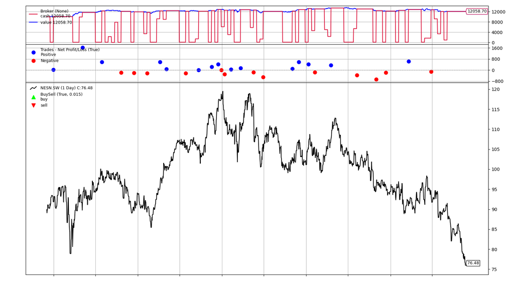

|  | Category | Metric | NESN.SW |
| --- | --- | --- | --- |
| 0 | Fundamentals | Starting Portfolio Value | 10000.00 |
| 1 | Fundamentals | Final Portfolio Value | 12058.70 |
| 2 | Fundamentals | Net Profit | 2058.70 |
| 3 | Fundamentals | Profit (%) | 20.59 |
| 4 | Fundamentals | Annualized Return (%) | 3.81 |
| 5 | Fundamentals | Max Drawdown (%) | 12.34 |
| 6 | Fundamentals | Calmar Ratio | 0.31 |
| 7 | Fundamentals | Sharpe Ratio | 0.10 |
| 8 | Activity | Total Trades | 29.00 |
| 9 | Activity | Winning Trades | 15.00 |
| 10 | Activity | Losing Trades | 13.00 |
| 11 | Trade quality | Hit Rate (%) | 51.72 |
| 12 | Trade quality | Profit Factor | 1.83 |
| 13 | Trade quality | Average Win | 395.13 |
| 14 | Trade quality | Average Loss | -248.49 |

```python
resultsDF = createResultsDF()
timeRange = 5 * 365
resultsDF['NESN.SW'] = resultsDF['Metric'].map(runBacktest('NESN.SW', assets['consumer_staples']['NESN.SW'], SubsequenceDDTWStrategy,strategyArgs={'dataSeed': assets['consumer_staples']['NESN.SW'][:-timeRange]}, timeRange=timeRange)).round(2)
ipd.display(resultsDF)
```

```
Transaction log:
================
  - 2019-12-02: HOLD - No similar subsequencens found
  - 2019-12-16: HOLD - No similar subsequencens found
  - 2019-12-30: HOLD - No similar subsequencens found
  - 2020-01-13: HOLD - No similar subsequencens found
  - 2020-01-27: BUY - Adjusting allocation from 0.00 to target 1.00. Buy 132.21 shares at 74.88
  - 2020-02-10: HOLD - No similar subsequencens found
  - 2020-02-24: SELL - Adjusting allocation from 0.99 to target 0.00. Sell 132.21 shares at 72.44
  - 2020-03-09: BUY - Adjusting allocation from 0.00 to target 1.00. Buy 147.86 shares at 64.66
  - 2020-03-23: HOLD - Current allocation 0.99 already at target 1.00 or within rebalancing threshold (+/- 0.05) at 54.51
  - 2020-04-06: HOLD - No similar subsequencens found
  - 2020-04-20: HOLD - Current allocation 0.99 already at target 1.00 or within rebalancing threshold (+/- 0.05) at 67.28
  - 2020-05-04: SELL - Adjusting allocation from 0.99 to target 0.00. Sell 147.86 shares at 71.22
  - 2020-05-18: HOLD - Current allocation 0.00 already at target 0.00 or within rebalancing threshold (+/- 0.05) at 76.73
  - 2020-06-01: HOLD - Current allocation 0.00 already at target 0.00 or within rebalancing threshold (+/- 0.05) at 78.40
  - 2020-06-15: BUY - Adjusting allocation from 0.00 to target 1.00. Buy 125.69 shares at 83.55
  - 2020-06-29: HOLD - No similar subsequencens found
  - 2020-07-13: SELL - Adjusting allocation from 0.99 to target 0.00. Sell 125.69 shares at 93.03
  - 2020-07-27: BUY - Adjusting allocation from 0.00 to target 1.00. Buy 126.20 shares at 92.38
  - 2020-08-10: HOLD - Current allocation 0.99 already at target 1.00 or within rebalancing threshold (+/- 0.05) at 110.04
  - 2020-08-24: HOLD - Current allocation 0.99 already at target 1.00 or within rebalancing threshold (+/- 0.05) at 122.86
  - 2020-09-07: SELL - Adjusting allocation from 0.99 to target 0.00. Sell 126.20 shares at 118.08
  - 2020-09-21: BUY - Adjusting allocation from 0.00 to target 0.07. Buy 9.49 shares at 107.46
  - 2020-10-05: SELL - Adjusting allocation from 0.07 to target 0.00. Sell 9.49 shares at 113.72
  - 2020-10-19: BUY - Adjusting allocation from 0.00 to target 1.00. Buy 131.61 shares at 113.22
  - 2020-11-02: HOLD - No similar subsequencens found
  - 2020-11-16: HOLD - Current allocation 0.99 already at target 1.00 or within rebalancing threshold (+/- 0.05) at 117.64
  - 2020-11-30: SELL - Adjusting allocation from 0.99 to target 0.00. Sell 131.61 shares at 116.41
  - 2020-12-14: BUY - Adjusting allocation from 0.00 to target 1.00. Buy 128.37 shares at 119.08
  - 2020-12-28: SELL - Adjusting allocation from 0.99 to target 0.00. Sell 128.37 shares at 133.66
  - 2021-01-11: HOLD - Current allocation 0.00 already at target 0.00 or within rebalancing threshold (+/- 0.05) at 126.12
  - 2021-01-25: BUY - Adjusting allocation from 0.00 to target 1.00. Buy 122.41 shares at 139.76
  - 2021-02-08: SELL - Adjusting allocation from 0.99 to target 0.00. Sell 122.41 shares at 134.08
  - 2021-02-22: BUY - Adjusting allocation from 0.00 to target 1.00. Buy 132.80 shares at 123.39
  - 2021-03-08: HOLD - Current allocation 0.99 already at target 1.00 or within rebalancing threshold (+/- 0.05) at 113.95
  - 2021-03-22: HOLD - Current allocation 0.99 already at target 1.00 or within rebalancing threshold (+/- 0.05) at 120.84
  - 2021-04-05: HOLD - Current allocation 0.99 already at target 1.00 or within rebalancing threshold (+/- 0.05) at 123.30
  - 2021-04-19: HOLD - Current allocation 0.99 already at target 1.00 or within rebalancing threshold (+/- 0.05) at 132.05
  - 2021-05-03: SELL - Adjusting allocation from 0.99 to target 0.00. Sell 132.80 shares at 129.80
```

[output cut: 78 more lines]

```
  - 2024-05-13: SELL - Adjusting allocation from 0.99 to target 0.00. Sell 167.37 shares at 185.86
  - 2024-05-27: HOLD - Current allocation 0.00 already at target 0.00 or within rebalancing threshold (+/- 0.05) at 189.55
  - 2024-06-10: BUY - Adjusting allocation from 0.00 to target 1.00. Buy 160.99 shares at 192.68
  - 2024-06-24: SELL - Adjusting allocation from 0.99 to target 0.00. Sell 160.99 shares at 207.67
  - 2024-07-08: HOLD - Current allocation 0.00 already at target 0.00 or within rebalancing threshold (+/- 0.05) at 227.31
  - 2024-07-22: BUY - Adjusting allocation from 0.00 to target 1.00. Buy 149.23 shares at 223.46
  - 2024-08-05: HOLD - Current allocation 0.99 already at target 1.00 or within rebalancing threshold (+/- 0.05) at 208.80
  - 2024-08-19: SELL - Adjusting allocation from 0.99 to target 0.68. Sell 47.42 shares at 225.64
  - 2024-09-02: SELL - Adjusting allocation from 0.68 to target 0.19. Sell 73.52 shares at 228.75
  - 2024-09-16: SELL - Adjusting allocation from 0.18 to target 0.00. Sell 28.29 shares at 216.08
  - 2024-09-30: BUY - Adjusting allocation from 0.00 to target 1.00. Buy 144.20 shares at 232.74
  - 2024-10-14: SELL - Adjusting allocation from 0.99 to target 0.00. Sell 144.20 shares at 231.05
  - 2024-10-28: HOLD - Current allocation 0.00 already at target 0.00 or within rebalancing threshold (+/- 0.05) at 233.14
  - 2024-11-11: HOLD - No similar subsequencens found
  - 2024-11-25: BUY - Adjusting allocation from 0.00 to target 0.52. Buy 74.05 shares at 232.87
```

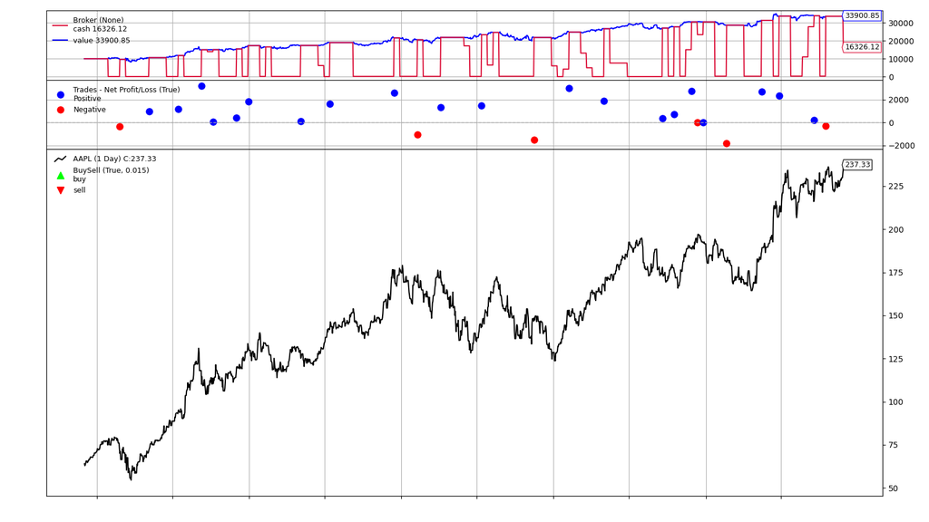

|  | Category | Metric | AAPL |
| --- | --- | --- | --- |
| 0 | Fundamentals | Starting Portfolio Value | 10000.00 |
| 1 | Fundamentals | Final Portfolio Value | 33900.85 |
| 2 | Fundamentals | Net Profit | 23900.85 |
| 3 | Fundamentals | Profit (%) | 239.01 |
| 4 | Fundamentals | Annualized Return (%) | 27.66 |
| 5 | Fundamentals | Max Drawdown (%) | 23.14 |
| 6 | Fundamentals | Calmar Ratio | 1.20 |
| 7 | Fundamentals | Sharpe Ratio | 0.87 |
| 8 | Activity | Total Trades | 27.00 |
| 9 | Activity | Winning Trades | 20.00 |
| 10 | Activity | Losing Trades | 6.00 |
| 11 | Trade quality | Hit Rate (%) | 74.07 |
| 12 | Trade quality | Profit Factor | 5.68 |
| 13 | Trade quality | Average Win | 1431.14 |
| 14 | Trade quality | Average Loss | -839.17 |

```python
resultsDF = createResultsDF()
timeRange = 5 * 365
resultsDF['AAPL'] = resultsDF['Metric'].map(runBacktest('AAPL', assets['tech']['AAPL'], SubsequenceDDTWStrategy,strategyArgs={'dataSeed': assets['tech']['AAPL'][:-timeRange]}, timeRange=timeRange)).round(2)
ipd.display(resultsDF)
```

Die Klasse SubsequenceDDTWStrategy und die darin verwendete Funktion recommendAllocation wurden iterativ entwickelt und anhand der Kursentwicklungen der Nestlé- und Apple-Aktien der letzten fünf Jahre getestet. Die Nestlé-Aktie wurde gezielt ausgewählt, da sie sowohl Aufwärts- als auch Abwärtsphasen aufweist und somit die Funktionalität der Strategie unter unterschiedlichen Marktbedingungen evaluiert werden konnte. Im Gegensatz dazu zeigte die Apple-Aktie, wie die meisten anderen analysierten Assets im Vergleich, in den letzten Jahren einen anhaltenden Aufwärtstrend, wodurch die Tests auch Situationen mit stetigem Wachstum abdeckten.

Im Rahmen dieser Tests wurden diverse wesentliche Erkenntnisse gewonnen, von denen die folgenden besonders hervorzuheben sind:

- Ressourcenintensive Berechnung ähnlicher Subsequenzen: Bereits früh zeigte sich, dass die tägliche Ermittlung ähnlicher Subsequenzen zur aktuellen Referenzsequenz äusserst ressourcenintensiv ist. Dies liegt unter anderem daran, dass jeweils jede Kombination zwischen Subsequenzen und Referenzsequenz getestet werden muss, was beinhaltet, dass von jeder Subsequenz separat die erste Ableitung berechnet und normalisiert wird (vgl. Kapitel 8). Die dadurch entstehenden langen Ausführungszeiten erwiesen sich sowohl während der Entwicklung als auch bei nachfolgenden Tests als unpraktikabel. Zur Lösung dieses Problems wurden zwei Optimierungen identifiziert und erfolgreich umgesetzt, ohne die Genauigkeit der Strategie wesentlich zu beeinträchtigen:
  - Reduktion der "lookbackPeriod": Anstelle einer Analyse der Kursentwicklung der letzten zehn Jahre wurde die "lookbackPeriod" auf fünf Jahre reduziert. Diese Anpassung halbierte den erforderlichen Rechenaufwand, da die Anzahl der zu prüfenden Subsequenzen entsprechend verringert wurde. Dabei stellte sich widererwarten heraus, dass die Genauigkeit der Prognosen oft gleich und vereinzelt gar leicht besser waren. Dies könnte möglicherweise damit zusammenhängen, dass ähnliche Sequenzen, die weniger weit in der Vergangenheit liegen, relevanter für die zukünftige Kursentwicklung sind als ältere Sequenzen. Ältere Muster könnten aufgrund veränderter Marktbedingungen an Aussagekraft verlieren, während aktuellere Daten stärker mit den bevorstehenden Bewegungen korrelieren.
  - Einschränkung der "Trading-Days": Die Analyse der Transaktionslogs zeigte, dass aufeinanderfolgende Tage häufig zu ähnlichen Zielallokationen führten, was aufgrund der Funktionsweise von DTW erwartbar ist. Dabei hatte jeweils nur der erste Tag signifikante Auswirkungen auf Käufe oder Verkäufe, während die Anpassungen an den Folgetagen meist marginal und nicht immer sinnvoll waren. Daher wurde entschieden, die DTW-Berechnungen nicht bei jeder Iteration durchzuführen, sondern die Handelstage, die der Strategie zur Verfügung stehen, einzuschränken, was wiederum die Anzahl an subsequence DTW-Berechnungen massiv reduzierte.
- Ursprünglich wurden die historischen Daten direkt von Backtrader bereitgestellt, wobei die ersten 10 bzw. 5 Jahre als Warm-Up-Phase definiert wurden. In dieser Phase lernte die Strategie ausschliesslich die Kursentwicklung, suchte jedoch keine Subsequenzen und erteilte keine Orders. Diese Herangehensweise funktionierte grundsätzlich gut, führte jedoch zu einem wesentlichen Nachteil: In den Plots wurde die erste Hälfte oder sogar bis zu zwei Drittel der Darstellung von der Warm-Up-Phase eingenommen, die keine relevanten oder interessanten Informationen enthielt. Dadurch waren die wirklich relevanten Details der Test- bzw. Trading-Phase nur schwer erkennbar. Um dieses Problem zu beheben, wurde eine alternative Implementierung mithilfe des dataSeed-Ansatzes entwickelt, die eine bessere Fokussierung auf die wesentlichen Informationen ermöglicht.
- Während der Tests zeigte sich zudem, dass es in Funktionen wie recommendAllocation nicht immer sinnvoll ist, eine komplexe Lösung mit möglichst vielen mutmasslich relevanten Parametern anzustreben. Einerseits erhöhte dies die Fehleranfälligkeit der Implementierung, andererseits führte es oft nicht zu besseren Ergebnissen, sondern vielmehr zu Verbesserungen in nur spezifischen Situationen. Diese Erkenntnis erinnert an das Verhalten von Machine-Learning-Anwendungen, bei denen komplexe Modelle zu Overfitting neigen. Daher war es entscheidend, bei der Umsetzung eine ausgewogene Balance zwischen der Leistungsfähigkeit und der Komplexität der Implementation zu finden.

Anhand der beiden genannten Assets wurden in zahlreichen Iterationen explorativ geeignete Parametrisierungen (bezüglich subsequenceLength, trendSensitivity, rebalancingThreshold, daysAhead und tradingInterval) und Implementierungen der verwendeten Formeln erarbeitet. Letztendlich wurde die oben dokumentierte Kombination bzw. Strategie identifiziert, die sowohl für NESN.SW als auch AAPL überzeugende Ergebnisse liefert. Im Vergleich zu den drei Referenzstrategien (MovingAverageCrossoverStrategy, BuyAndHoldStrategy, CostAveragingStrategy) zeigt diese Strategie auf der herausfordernden Nestlé-Aktie als einzige einen positiven Profit und einen Annualized Return von 3.81 %. Gleichzeitig liegt der Max Drawdown mit 12.34 % etwa zwei Drittel unter dem der Referenzstrategien.

Auch bei der Apple-Aktie erzielt die Strategie einen überdurchschnittlichen Annualized Return, der allerdings knapp von der BuyAndHoldStrategy übertroffen wird – ein Effekt, der auf den konstanten Aufwärtstrend dieses Assets zurückzuführen ist. Sollte es zukünftig zu einem Rücksetzer kommen, könnte die SubsequenceDDTWStrategy im Vergleich zur BuyAndHoldStrategy von ihrer Anpassungsfähigkeit profitieren. Die weiteren relevanten Kennzahlen, einschliesslich des Max Drawdown, bewegen sich auf einem ähnlichen Niveau wie bei den Referenzstrategien.

Die bisherigen Ergebnisse deuten darauf hin, dass die Strategie in diesem begrenzten Testumfeld mit zwei Assets sowohl eine solide Performance als auch eine vielversprechende Generalisierbarkeit bei unterschiedlichen Assettypen und Marktbedingungen aufweist. Im nächsten Unterkapitel wird die Strategie umfassend mit einer breiteren Auswahl an Assets getestet und erneut mit den Referenzstrategien verglichen, um zu prüfen, ob diese Erkenntnisse auch unter vielfältigeren Bedingungen bestätigt werden und die Strategie als robust bewertet werden kann.

### 9.3. Test und Beurteilung von DTW-Strategie

In diesem Unterkapitel wird die zuvor entwickelte SubsequenceDDTWStrategy umfassend gegen alle definierten Testassets geprüft und deren Ergebnisse mit den drei Referenzstrategien verglichen.

```python
# comperative asset analysis for all fetched assets for SubsequenceDDTWStrategy (transaction log and plot disabled for better readability --> only show results table)
resultsDF = createResultsDF()
timeRange = 5 * 365
riskFreeRate = getAverageRiskfreeRate(dates[-timeRange], dates[-1]) # calculate the average risk-free rate for the last 5 years based on 10-year US Treasury yield to use it for all assetes (even if the assets are traded abroad --> allows better comparability for the Sharpe ratio for the different assets)
for assetType in assets.keys():
    for ticker in assets[assetType].keys():
        print(f"Running backtest simulation for {ticker} ({assetType})...")
        resultsDF[ticker] = resultsDF['Metric'].map(runBacktest(ticker, assets[assetType][ticker], SubsequenceDDTWStrategy, strategyArgs={'dataSeed': assets[assetType][ticker][:-timeRange]}, timeRange=timeRange, riskFreeRate=riskFreeRate, noTransactionLog=True, noPlot=True)).round(2)

# add summary columns to the results dataframe
resultsDF = addSummaryColumnsToDF(resultsDF)

print("\n\nResults for SubsequenceDDTWStrategy:")
ipd.display(resultsDF)
```

```
Running backtest simulation for AAPL (tech)...
Running backtest simulation for MSFT (tech)...
Running backtest simulation for GOOGL (tech)...
Running backtest simulation for NESN.SW (consumer_staples)...
Running backtest simulation for PG (consumer_staples)...
Running backtest simulation for UL (consumer_staples)...
Running backtest simulation for ABBN.SW (industrial)...
Running backtest simulation for SIEGY (industrial)...
Running backtest simulation for GE (industrial)...
Running backtest simulation for GC=F (precious_metals)...
Running backtest simulation for SI=F (precious_metals)...
Running backtest simulation for PL=F (precious_metals)...
Running backtest simulation for ^SSMI (market_indexes)...
Running backtest simulation for ^GDAXI (market_indexes)...
Running backtest simulation for ^GSPC (market_indexes)...


Results for SubsequenceDDTWStrategy:
```

|  | Category | Metric | AAPL | MSFT | GOOGL | NESN.SW | PG | UL | ABBN.SW | SIEGY | GE | GC=F | SI=F | PL=F | ^SSMI | ^GDAXI | ^GSPC | Average | Standard Deviation |
| --- | --- | --- | --- | --- | --- | --- | --- | --- | --- | --- | --- | --- | --- | --- | --- | --- | --- | --- | --- |
| 0 | Fundamentals | Starting Portfolio Value | 10000.00 | 10000.00 | 10000.00 | 10000.00 | 10000.00 | 10000.00 | 10000.00 | 10000.00 | 10000.00 | 10000.00 | 10000.00 | 10000.00 | 10000.00 | 10000.00 | 10000.00 | 10000.00 | 0.00 |
| 1 | Fundamentals | Final Portfolio Value | 33900.91 | 19001.02 | 24720.86 | 12058.69 | 16637.73 | 12952.71 | 17257.02 | 20498.40 | 24214.95 | 13100.38 | 14481.08 | 10499.83 | 13803.94 | 14365.05 | 17630.59 | 17674.88 | 6147.43 |
| 2 | Fundamentals | Net Profit | 23900.91 | 9001.02 | 14720.86 | 2058.69 | 6637.73 | 2952.71 | 7257.02 | 10498.40 | 14214.95 | 3100.38 | 4481.08 | 499.83 | 3803.94 | 4365.05 | 7630.59 | 7674.88 | 6147.43 |
| 3 | Fundamentals | Profit (%) | 239.01 | 90.01 | 147.21 | 20.59 | 66.38 | 29.53 | 72.57 | 104.98 | 142.15 | 31.00 | 44.81 | 5.00 | 38.04 | 43.65 | 76.31 | 76.75 | 61.47 |
| 4 | Fundamentals | Annualized Return (%) | 27.66 | 13.70 | 19.84 | 3.81 | 10.72 | 5.31 | 11.53 | 15.44 | 19.35 | 5.55 | 7.69 | 0.98 | 6.66 | 7.51 | 12.01 | 11.18 | 7.12 |
| 5 | Fundamentals | Max Drawdown (%) | 23.14 | 22.57 | 29.13 | 12.34 | 12.70 | 12.52 | 21.74 | 46.39 | 29.48 | 13.91 | 33.91 | 27.42 | 17.32 | 25.79 | 22.38 | 23.38 | 9.33 |
| 6 | Fundamentals | Calmar Ratio | 1.20 | 0.61 | 0.68 | 0.31 | 0.84 | 0.42 | 0.53 | 0.33 | 0.66 | 0.40 | 0.23 | 0.04 | 0.38 | 0.29 | 0.54 | 0.50 | 0.28 |
| 7 | Fundamentals | Sharpe Ratio | 0.87 | 0.50 | 0.60 | 0.10 | 0.56 | 0.40 | 0.64 | 0.60 | 1.09 | 0.36 | 0.54 | -0.10 | 0.48 | 0.59 | 0.92 | 0.54 | 0.30 |
| 8 | Activity | Total Trades | 28.00 | 28.00 | 30.00 | 27.00 | 24.00 | 32.00 | 31.00 | 35.00 | 28.00 | 29.00 | 31.00 | 32.00 | 26.00 | 24.00 | 22.00 | 28.47 | 3.52 |
| 9 | Activity | Winning Trades | 21.00 | 21.00 | 18.00 | 15.00 | 15.00 | 21.00 | 18.00 | 21.00 | 19.00 | 15.00 | 18.00 | 13.00 | 15.00 | 19.00 | 16.00 | 17.67 | 2.69 |
| 10 | Activity | Losing Trades | 6.00 | 7.00 | 12.00 | 12.00 | 8.00 | 10.00 | 12.00 | 13.00 | 8.00 | 13.00 | 13.00 | 19.00 | 10.00 | 5.00 | 6.00 | 10.27 | 3.71 |
| 11 | Trade quality | Hit Rate (%) | 75.00 | 75.00 | 60.00 | 55.56 | 62.50 | 65.62 | 58.06 | 60.00 | 67.86 | 51.72 | 58.06 | 40.62 | 57.69 | 79.17 | 72.73 | 62.64 | 10.18 |
| 12 | Trade quality | Profit Factor | 4.92 | 2.19 | 2.51 | 1.60 | 3.05 | 2.60 | 2.32 | 2.55 | 3.80 | 2.51 | 1.60 | 1.05 | 3.27 | 2.37 | 11.46 | 3.19 | 2.47 |
| 13 | Trade quality | Average Win | 1410.00 | 789.40 | 1358.31 | 367.42 | 558.49 | 272.21 | 709.01 | 894.22 | 1029.38 | 371.54 | 664.71 | 788.74 | 363.16 | 397.24 | 522.51 | 699.76 | 354.46 |
| 14 | Trade quality | Average Loss | -1003.68 | -1082.35 | -810.73 | -287.71 | -343.36 | -219.46 | -458.76 | -565.82 | -643.20 | -170.82 | -575.67 | -513.36 | -166.68 | -636.51 | -121.61 | -506.65 | 298.90 |

Die Tests mit den vorgesehenen 15 Assets bestätigten weitgehend, dass die SubsequenceDDTWStrategy konsistent gute Ergebnisse liefert. Bei allen 15 Assets konnte ein positiver Profit bzw. ein positiver annualized Return erzielt werden, während die anderen Strategien teils einzelne negative Ausreisser aufwiesen. Zudem erzielte die Strategie bei einigen Assets vergleichsweise hohe Profits, was ihre Leistungsfähigkeit zusätzlich unterstreicht.

Die Ergebnisse des vorherigen Kapitels werden damit über die 15 Test-Assets bestätigt, die fünf verschiedene Assetklassen umfassen (z. B. Aktien, Rohstoffe und Indizes, auch wenn bei Indizes nur indirekt investiert werden kann). Die Tests deckten unterschiedliche Marktbedingungen ab und zeigen, dass die Strategie eine solide und robuste Performance sowie eine vielversprechende Generalisierbarkeit auf verschiedene Marktphasen und Assettypen aufweist.

Nachfolgend werden die durchschnittlichen Werte für die Metriken mitsamt Standardabweichung der vier Strategien nochmals zusammenfassend dargestellt:

| Category | Metric | Average | Standard Deviation | Average | Standard Deviation | Average | Standard Deviation | Average | Standard Deviation |
| --- | --- | --- | --- | --- | --- | --- | --- | --- | --- |
| *Strategy* | *Used trading strategy* | **MAC** | **MAC** | **BAH** | **BAH** | **CA** | **CA** | **SDDTW** | **SDDTW** |
| Fundamentals | Starting Portfolio Value | 10000 | 0 | 10000 | 0 | 10000 | 0 | 10000 | 0 |
| Fundamentals | Final Portfolio Value | 16445 | 8083.99 | 20075.71 | 8748.94 | 14915.74 | 5201.82 | 17674.88 | 6147.43 |
| Fundamentals | Net Profit | 6445 | 8083.99 | 10075.71 | 8748.94 | 4915.74 | 5201.82 | 7674.88 | 6147.43 |
| Fundamentals | Profit (%) | 64.45 | 80.84 | 100.76 | 87.49 | 49.16 | 52.02 | 76.75 | 61.47 |
| Fundamentals | Annualized Return (%) | 8.84 | 9.48 | 13.32 | 10.03 | 7.49 | 6.81 | 11.18 | 7.12 |
| Fundamentals | Max Drawdown (%) | 26.8 | 6.55 | 36.42 | 9.71 | 19.06 | 6.24 | 23.38 | 9.33 |
| Fundamentals | Calmar Ratio | 0.36 | 0.37 | 0.37 | 0.28 | 0.41 | 0.3 | 0.5 | 0.28 |
| Fundamentals | Sharpe Ratio | 0.24 | 0.37 | 0.43 | 0.35 | 0.22 | 0.43 | 0.54 | 0.3 |
| Activity | Total Trades | 10.67 | 1.72 |  |  |  |  | 28.47 | 3.52 |
| Activity | Winning Trades | 4.47 | 1.19 |  |  |  |  | 17.67 | 2.69 |
| Activity | Losing Trades | 5.67 | 1.95 |  |  |  |  | 10.27 | 3.71 |
| Trade quality | Hit Rate (%) | 42.24 | 11.93 |  |  |  |  | 62.64 | 10.18 |
| Trade quality | Profit Factor | 3.01 | 2.8 |  |  |  |  | 3.19 | 2.47 |
| Trade quality | Average Win | 2210.4 | 2033.75 |  |  |  |  | 699.76 | 354.46 |
| Trade quality | Average Loss | -688.66 | 329.61 |  |  |  |  | -506.65 | 298.9 |

- MAC = MovingAverageCrossoverStrategy
- BAH = BuyAndHoldStrategy
- CA = CostAveragingStrategy
- SDDTW = SubsequenceDDTWStrategy

Die Analyse zeigt, dass sich die SubsequenceDDTWStrategy (SDDTW) in Bezug auf Profit und Annualized Return deutlich gegenüber der MovingAverageCrossoverStrategy (MAC) und der CostAveragingStrategy (CA) absetzen kann. Mit einem durchschnittlichen Profit von 76,75 % und einer Annualized Return von 11,18 % liegt SDDTW hinter der BuyAndHoldStrategy (BAH), die mit einem durchschnittlichen Profit von 100,76 % und einem Annualized Return von 13,32 % die beste Performance erzielt. Dieses Ergebnis könnte jedoch, wie bereits analysiert, mit der aktuell eher positiven Marktlage mit wenigen Rücksetzern sowie der spezifischen Zusammensetzung der Testassets zusammenhängen.

Auch im Hinblick auf den maximalen Drawdown zeigt SDDTW eine solide Performance: Mit einem Max Drawdown von 23,38 % schneidet die Strategie besser ab als MAC (26,8 %) und BAH (36,42 %), wird jedoch knapp von CA (19,06 %) übertroffen. BAH schneidet bei diesem Kriterium vergleichsweise schlecht ab, was auf die Volatilität dieser Strategie hinweist.

Besonders hervorzuheben ist die Performance von SDDTW bei den Risikokennzahlen: Mit einem Sharpe Ratio von 0,54 und einem Calmar Ratio von 0,5 erzielt SDDTW die besten Werte unter den vier Strategien. Dies zeigt, dass SDDTW nicht nur in Bezug auf Rendite, sondern auch in der Risikoanpassung besonders effektiv ist. Generell verdeutlichen diese Kennzahlen, dass SDDTW zwar nicht das aggressivste Renditepotenzial aufweist, dafür jedoch eine gute Balance zwischen Gewinn und Risiko bietet.

Insgesamt zeigt die SDDTW-Strategie eine ausgewogene Mischung aus hoher Profitabilität, moderatem Risiko und einer starken risikoadjustierten Performance, was sie zu einer robusten Wahl im vorliegenden Vergleich macht.

Die Ergebnisse dieses Tests, der auf 15 Assets über einen Zeitraum von 5 Jahren und vier Strategien basiert, sollten jedoch mit Vorsicht interpretiert werden, da sie nur einen kleinen Ausschnitt der möglichen Markt- und Anlagesituationen abdecken. Es gibt eine Vielzahl weiterer Assets, Asset-Typen, Marktlagen und Strategien, die in der Analyse nicht berücksichtigt wurden. Dennoch legen die Ergebnisse nahe, dass die Subsequence DTW-Strategie aufgrund ihrer Methodik durchaus in der Lage sein könnte, sinnvolle Handelssignale zu generieren.

Es ist jedoch zu beachten, dass die untersuchten Strategien bewusst isoliert getestet wurden, um ihre spezifischen Merkmale gezielt zu bewerten. Dies ist in der Praxis zwar ein möglicher Ansatz, andererseits sind aber auch fortgeschrittene Ansätze denkbar, bei denen Handelssignale aus unterschiedlichen Quellen beziehungsweise Analysen aggregiert und je nach Kontext gewichtet werden, bevor ein abschliessender Handelsentscheid getroffen wird. Letzteres Vorgehen entspräche einem Ensemble-Ansatz, der auch aus dem Bereich des Machine Learning bekannt ist. Dort haben sich Ensemble-Methoden wie der Random Forest häufig als überlegen gegenüber isolierten Modellen erwiesen, da sie die Schwächen einzelner Ansätze ausgleichen und eine robustere Gesamtleistung erzielen können. Daraus ergibt sich die Hypothese, dass ein solcher Ansatz auch bei Handelsstrategien die Ergebnisse verbessern könnte, indem die Stärken verschiedener Methoden kombiniert werden, um eine ausgewogenere und flexiblere Entscheidungsfindung zu ermöglichen.

Die vorliegende Analyse konzentriert sich zudem bewusst auf den Handel mit Einzel-Assets, um die durch ein umfassendes Portfoliomanagement entstehende Komplexität und Variabilität auszuklammern. Diese Einschränkung ermöglicht eine gezielte Betrachtung des Hauptthemas, nämlich der Anwendung von DTW (Dynamic Time Warping). In der Praxis würden jedoch bei der Analyse von Portfolios zusätzliche Herausforderungen auftreten, wie etwa Zielkonflikte bei der Kapitalallokation auf vielversprechende Assets. Gleichzeitig ergeben sich durch die Berücksichtigung von Portfolios auch Potenziale, wie Diversifikationseffekte oder die Optimierung des Gesamtrisikos, die in dieser Arbeit nicht untersucht wurden.

## 10. DTW Anwendung: Clustering von Assets (Zusatzkapitel)

Während der Auseinandersetzung mit DTW entstand die Idee, dass DTW möglicherweise dazu genutzt werden könnte, einzelne Assets anhand ihres Kursverlaufs in verschiedene Asset-Typen (z. B. Technologie, Konsumgüter, Metalle, Indizes usw.) zu clustern. Dies würde es potenziell ermöglichen, aus dem Kursverlauf eines unbekannten Assets Rückschlüsse auf dessen Typ zu ziehen und es entsprechend einzuordnen. Die Idee basiert auf der Annahme, dass Assets desselben Typs häufig ähnliche Verhaltensmuster aufweisen und dass diese ähnlichen Phasen in der Regel die Phasen mit grösseren Unterschieden überwiegen.

Um diese Idee zu testen, wurden die DTW- und DDTW-Distanzen (nach entsprechender Glättung und Standardisierung) zwischen allen Assets berechnet und in entsprechende Confusion-Matrizen übertragen. Dabei wurde darauf geachtet, dass die Assets in den Matrizen entsprechend ihrer Asset-Typen angeordnet sind. Diese Darstellung ermöglicht es, innerhalb der Confusion-Matrix Submatrizen zu identifizieren, die die Distanzen innerhalb eines Asset-Typs darstellen (in den Grafiken rot markiert). Für ein erfolgreiches Clustering, das ausschliesslich auf DTW basiert, müsste sichergestellt sein, dass die Werte innerhalb dieser Submatrizen deutlich von denen ausserhalb abweichen, um eine zuverlässige und eindeutige Clusterzuweisung zu ermöglichen.

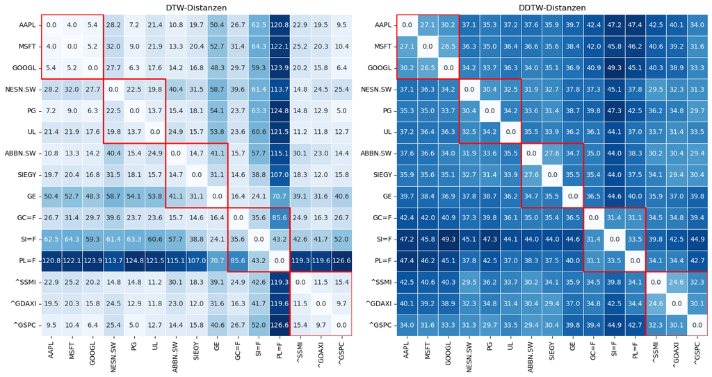

```python
# prepare assets for the analysis
compAssets = []
for assetType in assets.keys():
    for ticker in assets[assetType].keys():
        compAssets.append({
            'assetType': assetType,
            'ticker': ticker,
            'smoothedAndStandardizedPrice': standardizeData(smoothTimeSeries(assets[assetType][ticker])),
            'smoothedAndStandardizedDerivatives': standardizeData(calculateDerivatives(smoothTimeSeries(assets[assetType][ticker]))),
        })

# prepare empty matrices for the DTW and DDTW distances
dtwMatrix = np.zeros((len(compAssets),len(compAssets)))
ddtwMatrix = np.zeros((len(compAssets),len(compAssets)))

# calculate the DTW and DDTW distances for all pairs of assets
for i,j in list(itertools.combinations(range(len(compAssets)),2)):
    dtwMatrix[i,j] = tslearn.metrics.dtw(compAssets[i]['smoothedAndStandardizedPrice'],compAssets[j]['smoothedAndStandardizedPrice'])
    dtwMatrix[j,i] = dtwMatrix[i,j] # Symmetrie
    ddtwMatrix[i,j] = tslearn.metrics.dtw(compAssets[i]['smoothedAndStandardizedDerivatives'],compAssets[j]['smoothedAndStandardizedDerivatives'])
    ddtwMatrix[j,i] = ddtwMatrix[i,j] # Symmetrie

# prepare the asset types and unique types for the plot
assetTypes = [x['assetType'] for x in compAssets]
uniqueTypes = list(set(assetTypes))

# helper function to draw group boxes
def draw_group_boxes(ax, assetTypes, uniqueTypes, lineColor="black", lineWidth=2):
    startIdx = 0
    for utype in uniqueTypes:
        size = assetTypes.count(utype)
        rect = matplotlib.patches.Rectangle((startIdx, startIdx),size,size,linewidth=lineWidth,edgecolor=lineColor,facecolor='none')
        ax.add_patch(rect)
        startIdx += size

# plot (d)dtw matrices
plt.figure(figsize=(15, 8))

plt.subplot(1, 2, 1)
plt.title("DTW-Distanzen")
hm = sns.heatmap(dtwMatrix, annot=True, fmt=".1f", cmap='Blues', linewidths=0.5, xticklabels=[x['ticker'] for x in compAssets], yticklabels=[x['ticker'] for x in compAssets], cbar=False)
draw_group_boxes(hm, assetTypes, uniqueTypes, lineColor='red')

plt.subplot(1, 2, 2)
plt.title("DDTW-Distanzen")
hm=sns.heatmap(ddtwMatrix, annot=True, fmt=".1f", cmap='Blues', linewidths=0.5, xticklabels=[x['ticker'] for x in compAssets], yticklabels=[x['ticker'] for x in compAssets], cbar=False)
draw_group_boxes(hm, assetTypes, uniqueTypes, lineColor='red')

plt.tight_layout()
plt.show()
```

Obwohl die markierten Bereiche tendenziell geringere Werte aufweisen und somit eine stärkere Ähnlichkeit innerhalb der Submatrizen andeuten, ist deutlich erkennbar, dass auch ausserhalb dieser Bereiche häufig tiefe Distanzen auftreten. Dies zeigt, dass Assets unterschiedlicher Typen oftmals ähnliche Kursverläufe aufweisen können. Diese Beobachtung gilt sowohl für die DTW- als auch für die DDTW-Confusionmatrix.

Aufgrund dieser Erkenntnisse scheint es nicht direkt möglich zu sein, Asset-Typen ausschliesslich anhand des Kursverlaufs und DTW automatisch zu clustern. Ein möglicher Grund dafür ist, dass Kursverläufe nicht allein durch den Asset-Typ geprägt werden, sondern auch von externen Faktoren wie makroökonomischen Entwicklungen, globalen Trends oder marktübergreifenden Ereignissen beeinflusst werden. Darüber hinaus können kurzfristige Schwankungen und Marktbewegungen ähnliche Muster erzeugen, selbst wenn die zugrunde liegenden Assets fundamental unterschiedlich sind.

Ein weiterer Erklärungsansatz könnte in der Limitierung der gewählten Distanzmetrik liegen: Während DTW zeitliche Muster gut erfasst, berücksichtigt sie keine zusätzlichen kontextuellen Informationen wie fundamentale Daten, Liquidität oder sektorspezifische Korrelationen. Solche Informationen könnten jedoch entscheidend sein, um eine klarere Trennung zwischen Asset-Typen zu ermöglichen und die Zuverlässigkeit eines solchen Clusterings zu verbessern.

Nachfolgend wird die Erkenntnis, dass ein sinnvolles und zuverlässiges Clustering der Asset-Typen ausschliesslich auf Basis der (D)DTW-Distanzen kaum möglich ist, anhand von Scatterplots weiter verdeutlicht. Für ein erfolgreiches Clustering müssten die Punkte gleicher Farbe (entsprechend des gleichen Asset-Typs) in den Scatterplots eng beieinander liegen, während Punkte unterschiedlicher Farben möglichst grosse Abstände aufweisen sollten.

Wie bereits in den Confusion-Matrizen erkennbar, zeigt sich auch in den Scatterplots, dass Assets desselben Typs häufig relativ nahe beieinander liegen (z. B. bei den Tech-Aktien). Gleichzeitig gibt es jedoch auch Assets verschiedener Typen, die eine hohe Ähnlichkeit aufweisen, was eine eindeutige Trennung erschwert. Dies bestätigt die vorherige Beobachtung, dass allein die (D)DTW-Distanzen nicht ausreichen, um eine klare und zuverlässige Clusterbildung der Asset-Typen zu ermöglichen.

Die beiden vorgestellten Ansätze können jedoch sinnvoll genutzt werden, um Ausreisser im Hinblick auf den Kursverlauf zu identifizieren. Besonders Platin (PL=F) zeigt, insbesondere basierend auf den DTW-Distanzen, ein deutlich abweichendes Verhalten im Vergleich zu den anderen Assets. Diese Beobachtung wird auch durch die Analyse des Kursverlaufs in Kapitel 5 bestätigt, wo der Verlauf von Platin im Vergleich zu den anderen Assets sichtbar heraussticht.

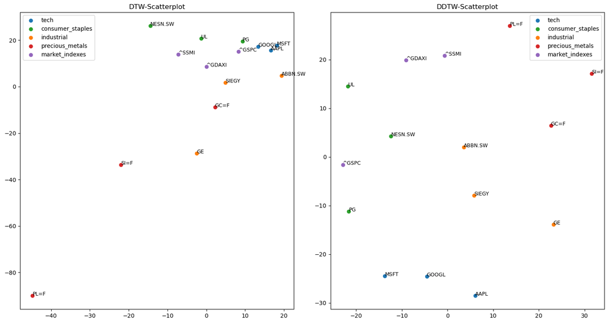

```python
# use multidimensional scaling (MDS) for dimensionality reduction to 2D to visualize the distances between the assets
mds = sklearn.manifold.MDS(n_components=2, dissimilarity='precomputed', normalized_stress='auto', random_state=42)

# calculate the MDS positions for the DTW and DDTW distances
dtw_positions = mds.fit_transform(dtwMatrix)
ddtw_positions = mds.fit_transform(ddtwMatrix)

# prepare the asset types and unique types for the plot
uniqueTypes = list(set([x['assetType'] for x in compAssets]))
type_colors = {atype: f"C{i}" for i, atype in enumerate(uniqueTypes)}

# scatterplot for DTW distances
plt.figure(figsize=(15, 8))
plt.subplot(1, 2, 1)
addedLabels = []
for i, asset in enumerate(compAssets):
    plt.scatter(dtw_positions[i, 0], dtw_positions[i, 1], color=type_colors[asset['assetType']], label=asset['assetType'] if asset['assetType'] not in addedLabels else None)
    plt.text(dtw_positions[i, 0], dtw_positions[i, 1], asset['ticker'], fontsize=9)
    addedLabels.append(asset['assetType'])
plt.title("DTW-Scatterplot")
plt.legend()

# scatterplot for DDTW distances
plt.subplot(1, 2, 2)
addedLabels = []
for i, asset in enumerate(compAssets):
    plt.scatter(ddtw_positions[i, 0], ddtw_positions[i, 1], color=type_colors[asset['assetType']], label=asset['assetType'] if asset['assetType'] not in addedLabels else None)
    plt.text(ddtw_positions[i, 0], ddtw_positions[i, 1], asset['ticker'], fontsize=9)
    addedLabels.append(asset['assetType'])
plt.title("DDTW-Scatterplot")
plt.legend()

plt.tight_layout()
plt.show()
```